# Evolutionary generation and maintenance of diversity is promoted by several small reserves

```r
for (i in 1:length(cons.data$Update) ) {
  if(cons.data$Update[i] < 100000) {
    cons.data$Early.Termination[i] <- 1
  }
  if(cons.data$Update[i] == 100000) {
    cons.data$Early.Termination[i] <- 0
  }
  if(cons.data$Patches[i] == 0) {
    cons.data$Protected[i] <- 0
  }
  if(cons.data$Patches[i] > 0) {
    cons.data$Protected[i] <- 1
  }
}



cons.data$Killed.Factor <- factor(cons.data$Killed)
cons.data$Patches.Factor <- factor(cons.data$Patches)

anova(lm(Early.Termination ~ Ecology + Protected + Initial.Pop, data=cons.data, na.action=na.omit, model=T))
```

```
## Analysis of Variance Table
##
## Response: Early.Termination
##               Df Sum Sq Mean Sq  F value    Pr(>F)
## Ecology        1  0.920  0.9200 101.0162 < 2.2e-16 ***
## Protected      1  6.133  6.1333 673.4411 < 2.2e-16 ***
## Initial.Pop    9  0.347  0.0386   4.2382 1.687e-05 ***
## Residuals   9188 83.679  0.0091
## ---
## Signif. codes:  0 '***' 0.001 '**' 0.01 '*' 0.05 '.' 0.1 ' ' 1
```

```r
anova(lm(Early.Termination ~ Ecology + Protected + Killed, data=cons.data, na.action=na.omit, model=T))
```

```
## Analysis of Variance Table
##
## Response: Early.Termination
##             Df Sum Sq Mean Sq  F value Pr(>F)
## Ecology      1  0.920  0.9200 100.6950 <2e-16 ***
## Protected    1  6.133  6.1333 671.2999 <2e-16 ***
## Killed       1  0.007  0.0074   0.8083 0.3687
## Residuals 9196 84.019  0.0091
## ---
## Signif. codes:  0 '***' 0.001 '**' 0.01 '*' 0.05 '.' 0.1 ' ' 1
```

```r
anova(lm(Early.Termination ~ Ecology + Initial.Pop, data=cons.data, na.action=na.omit, model=T))
```

```
## Analysis of Variance Table
##
## Response: Early.Termination
##               Df Sum Sq Mean Sq F value    Pr(>F)
## Ecology        1  0.920 0.92000 94.1280 < 2.2e-16 ***
## Initial.Pop    9  0.347 0.03860  3.9492 4.886e-05 ***
## Residuals   9189 89.813 0.00977
## ---
## Signif. codes:  0 '***' 0.001 '**' 0.01 '*' 0.05 '.' 0.1 ' ' 1
```

```r
anova(lm(Early.Termination ~ Ecology + Killed, data=cons.data, na.action=na.omit, model=T))
```

```
## Analysis of Variance Table
##
## Response: Early.Termination
##             Df Sum Sq Mean Sq F value    Pr(>F)
## Ecology      1  0.920 0.92000  93.990 < 2.2e-16 ***
## Killed       1  0.137 0.13684  13.979 0.0001859 ***
## Residuals 9197 90.023 0.00979
## ---
## Signif. codes:  0 '***' 0.001 '**' 0.01 '*' 0.05 '.' 0.1 ' ' 1
```

```r
eco.cons.data <- subset(cons.data, Ecology=="Y")
evo.cons.data <- subset(cons.data, Ecology=="N")


anova(lm(Shannon.Diversity ~ Initial.Pop, data=eco.cons.data, na.action=na.omit, model=T))
```

```
## Analysis of Variance Table
##
## Response: Shannon.Diversity
##               Df  Sum Sq Mean Sq F value    Pr(>F)
## Initial.Pop    9 1021.78 113.531  898.39 < 2.2e-16 ***
## Residuals   4590  580.05   0.126
## ---
## Signif. codes:  0 '***' 0.001 '**' 0.01 '*' 0.05 '.' 0.1 ' ' 1
```

```r
anova(lm(Shannon.Diversity ~ Killed, data=eco.cons.data, na.action=na.omit, model=T))
```

```
## Analysis of Variance Table
##
## Response: Shannon.Diversity
##             Df  Sum Sq Mean Sq F value    Pr(>F)
## Killed       1   12.24 12.2384    35.4 2.884e-09 ***
## Residuals 4598 1589.59  0.3457
## ---
## Signif. codes:  0 '***' 0.001 '**' 0.01 '*' 0.05 '.' 0.1 ' ' 1
```

```r
anova(lm(Shannon.Diversity ~ Killed.Factor, data=eco.cons.data, na.action=na.omit, model=T))
```

```
## Analysis of Variance Table
##
## Response: Shannon.Diversity
##                 Df  Sum Sq Mean Sq F value    Pr(>F)
## Killed.Factor    5   16.01  3.2016  9.2747 8.441e-09 ***
## Residuals     4594 1585.82  0.3452
## ---
## Signif. codes:  0 '***' 0.001 '**' 0.01 '*' 0.05 '.' 0.1 ' ' 1
```

```r
anova(lm(Shannon.Diversity ~ Patches, data=eco.cons.data, na.action=na.omit, model=T))
```

```
## Analysis of Variance Table
##
## Response: Shannon.Diversity
##             Df  Sum Sq Mean Sq F value   Pr(>F)
## Patches      1    4.81  4.8053  13.835 0.000202 ***
## Residuals 4598 1597.02  0.3473
## ---
## Signif. codes:  0 '***' 0.001 '**' 0.01 '*' 0.05 '.' 0.1 ' ' 1
```

```r
anova(lm(Shannon.Diversity ~ Patches.Factor, data=eco.cons.data, na.action=na.omit, model=T))
```

```
## Analysis of Variance Table
##
## Response: Shannon.Diversity
##                  Df  Sum Sq Mean Sq F value    Pr(>F)
## Patches.Factor    8   97.37 12.1707   37.14 < 2.2e-16 ***
## Residuals      4591 1504.46  0.3277
## ---
## Signif. codes:  0 '***' 0.001 '**' 0.01 '*' 0.05 '.' 0.1 ' ' 1
```

```r
foo <- subset(eco.cons.data, Patches > 0)
bah <- subset(evo.cons.data, Patches > 0)

anova(lm(Shannon.Diversity ~ Patches.Factor, data=foo, na.action=na.omit, model=T))
```

```
## Analysis of Variance Table
##
## Response: Shannon.Diversity
##                  Df  Sum Sq Mean Sq F value Pr(>F)
## Patches.Factor    7    0.86 0.12248  0.4169 0.8924
## Residuals      3992 1172.73 0.29377
```

```r
anova(lm(Average.Task.Diversity ~ Patches.Factor, data=foo, na.action=na.omit, model=T))
```

```
## Analysis of Variance Table
##
## Response: Average.Task.Diversity
##                  Df Sum Sq Mean Sq F value Pr(>F)
## Patches.Factor    7    0.2 0.02526  0.0168      1
## Residuals      3992 6007.1 1.50478
```

```r
anova(lm(Average.Phenotype.Diversity ~ Patches.Factor, data=foo, na.action=na.omit, model=T))
```

```
## Analysis of Variance Table
##
## Response: Average.Phenotype.Diversity
##                  Df  Sum Sq  Mean Sq F value Pr(>F)
## Patches.Factor    7   0.027 0.003923  0.0502 0.9998
## Residuals      3992 312.063 0.078172
```

```r
anova(lm(Unique.Phenotypes.Task ~ Patches.Factor, data=foo, na.action=na.omit, model=T))
```

```
## Analysis of Variance Table
##
## Response: Unique.Phenotypes.Task
##                  Df Sum Sq Mean Sq F value   Pr(>F)
## Patches.Factor    7   24.2  3.4634  3.2026 0.002193 **
## Residuals      3992 4317.0  1.0814
## ---
## Signif. codes:  0 '***' 0.001 '**' 0.01 '*' 0.05 '.' 0.1 ' ' 1
```

```r
anova(lm(Unique.Phenotype.Count ~ Patches.Factor, data=foo, na.action=na.omit, model=T))
```

```
## Analysis of Variance Table
##
## Response: Unique.Phenotype.Count
##                  Df Sum Sq Mean Sq F value    Pr(>F)
## Patches.Factor    7   37.0  5.2913  4.4124 6.805e-05 ***
## Residuals      3992 4787.2  1.1992
## ---
## Signif. codes:  0 '***' 0.001 '**' 0.01 '*' 0.05 '.' 0.1 ' ' 1
```

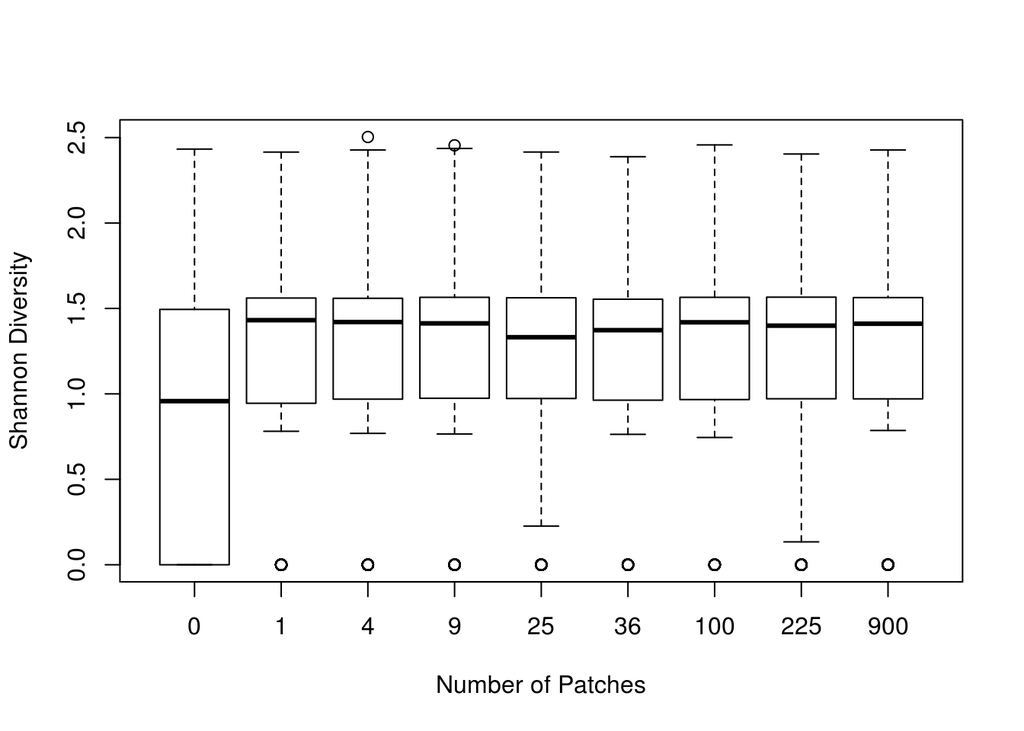

```r
plot(x=eco.cons.data$Patches.Factor, y=eco.cons.data$Shannon.Diversity, xlab="Number of Patches", ylab="Shannon Diversity")
```

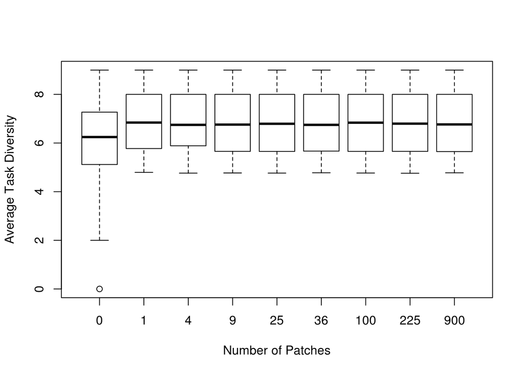

```r
plot(x=eco.cons.data$Patches.Factor, y=eco.cons.data$Average.Task.Diversity, xlab="Number of Patches", ylab="Average Task Diversity")
```

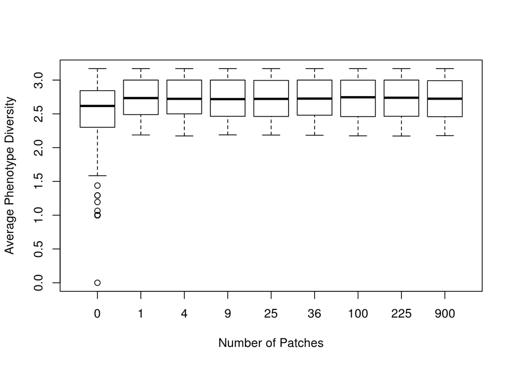

```r
plot(x=eco.cons.data$Patches.Factor, y=eco.cons.data$Average.Phenotype.Diversity, xlab="Number of Patches", ylab="Average Phenotype Diversity")
```

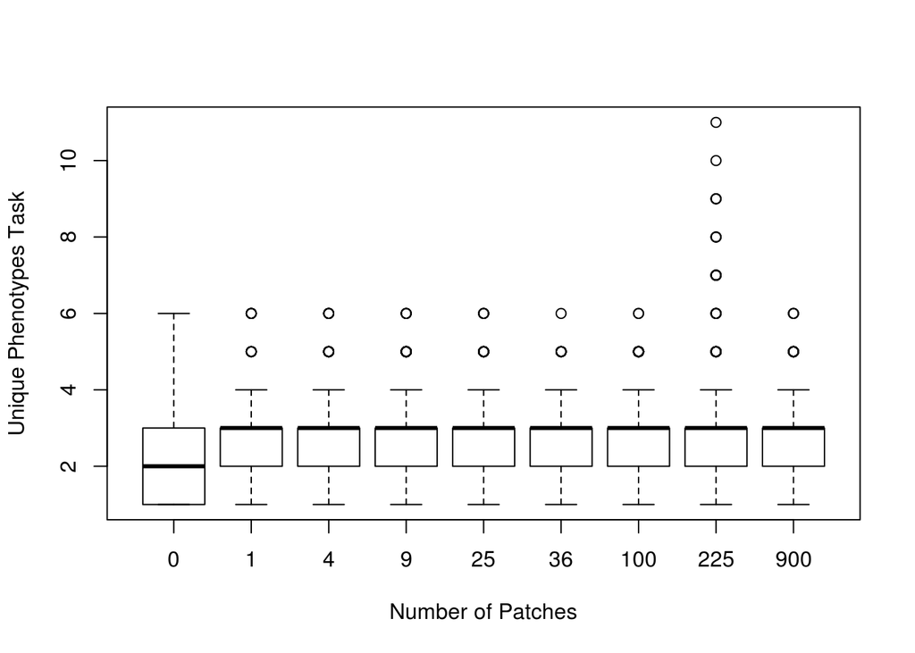

```r
plot(x=eco.cons.data$Patches.Factor, y=eco.cons.data$Unique.Phenotypes.Task, xlab="Number of Patches", ylab="Unique Phenotypes Task")
```

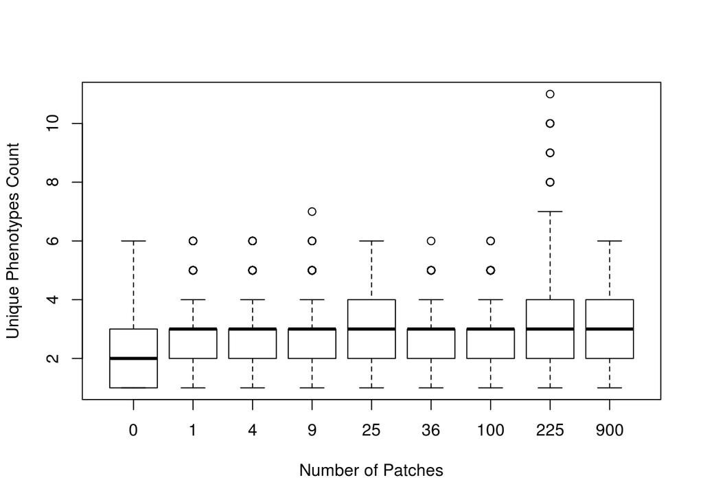

```r
plot(x=eco.cons.data$Patches.Factor, y=eco.cons.data$Unique.Phenotype.Count, xlab="Number of Patches", ylab="Unique Phenotypes Count")
```

```r
anova(lm(Shannon.Diversity ~ Patches.Factor, data=bah, na.action=na.omit, model=T))
```

```
## Analysis of Variance Table
##
## Response: Shannon.Diversity
##                  Df Sum Sq Mean Sq F value    Pr(>F)
## Patches.Factor    7 1760.0 251.422  408.34 < 2.2e-16 ***
## Residuals      3992 2457.9   0.616
## ---
## Signif. codes:  0 '***' 0.001 '**' 0.01 '*' 0.05 '.' 0.1 ' ' 1
```

```r
anova(lm(Average.Task.Diversity ~ Patches.Factor, data=bah, na.action=na.omit, model=T))
```

```
## Analysis of Variance Table
##
## Response: Average.Task.Diversity
##                  Df Sum Sq Mean Sq F value    Pr(>F)
## Patches.Factor    7 1276.8  182.40  136.14 < 2.2e-16 ***
## Residuals      3992 5348.6    1.34
## ---
## Signif. codes:  0 '***' 0.001 '**' 0.01 '*' 0.05 '.' 0.1 ' ' 1
```

```r
anova(lm(Average.Phenotype.Diversity ~ Patches.Factor, data=bah, na.action=na.omit, model=T))
```

```
## Analysis of Variance Table
##
## Response: Average.Phenotype.Diversity
##                  Df Sum Sq Mean Sq F value    Pr(>F)
## Patches.Factor    7  96.48 13.7822  76.001 < 2.2e-16 ***
## Residuals      3992 723.92  0.1813
## ---
## Signif. codes:  0 '***' 0.001 '**' 0.01 '*' 0.05 '.' 0.1 ' ' 1
```

```r
anova(lm(Unique.Phenotypes.Task ~ Patches.Factor, data=bah, na.action=na.omit, model=T))
```

```
## Analysis of Variance Table
##
## Response: Unique.Phenotypes.Task
##                  Df  Sum Sq Mean Sq F value    Pr(>F)
## Patches.Factor    7  827067  118152   308.1 < 2.2e-16 ***
## Residuals      3992 1530898     383
## ---
## Signif. codes:  0 '***' 0.001 '**' 0.01 '*' 0.05 '.' 0.1 ' ' 1
```

```r
anova(lm(Unique.Phenotype.Count ~ Patches.Factor, data=bah, na.action=na.omit, model=T))
```

```
## Analysis of Variance Table
##
## Response: Unique.Phenotype.Count
##                  Df   Sum Sq Mean Sq F value    Pr(>F)
## Patches.Factor    7  5687437  812491  134.61 < 2.2e-16 ***
## Residuals      3992 24094395    6036
## ---
## Signif. codes:  0 '***' 0.001 '**' 0.01 '*' 0.05 '.' 0.1 ' ' 1
```

```r
summary(lm(Shannon.Diversity ~ Patches.Factor, data=bah, na.action=na.omit, model=T))
```

```
##
## Call:
## lm(formula = Shannon.Diversity ~ Patches.Factor, data = bah,
##     na.action = na.omit, model = T)
##
## Residuals:
##     Min      1Q  Median      3Q     Max
## -3.4277 -0.4679  0.1084  0.5319  3.6221
##
## Coefficients:
##                   Estimate Std. Error t value Pr(>|t|)
## (Intercept)        2.51418    0.03509   71.65   <2e-16 ***
## Patches.Factor4    1.16416    0.04963   23.46   <2e-16 ***
## Patches.Factor9    1.54339    0.04963   31.10   <2e-16 ***
## Patches.Factor25   1.77829    0.04963   35.83   <2e-16 ***
## Patches.Factor36   1.81129    0.04963   36.50   <2e-16 ***
## Patches.Factor100  2.03546    0.04963   41.02   <2e-16 ***
## Patches.Factor225  2.16284    0.04963   43.58   <2e-16 ***
## Patches.Factor900  2.03898    0.04963   41.09   <2e-16 ***
## ---
## Signif. codes:  0 '***' 0.001 '**' 0.01 '*' 0.05 '.' 0.1 ' ' 1
##
## Residual standard error: 0.7847 on 3992 degrees of freedom
## Multiple R-squared:  0.4173, Adjusted R-squared:  0.4162
## F-statistic: 408.3 on 7 and 3992 DF,  p-value: < 2.2e-16
```

```r
summary(lm(Average.Task.Diversity ~ Patches.Factor, data=bah, na.action=na.omit, model=T))
```

```
##
## Call:
## lm(formula = Average.Task.Diversity ~ Patches.Factor, data = bah,
##     na.action = na.omit, model = T)
##
## Residuals:
##     Min      1Q  Median      3Q     Max
## -3.7750 -0.7741  0.0469  0.8035  3.4423
##
## Coefficients:
##                   Estimate Std. Error t value Pr(>|t|)
## (Intercept)        6.95332    0.05177  134.32   <2e-16 ***
## Patches.Factor4   -1.14412    0.07321  -15.63   <2e-16 ***
## Patches.Factor9   -1.43885    0.07321  -19.65   <2e-16 ***
## Patches.Factor25  -1.52318    0.07321  -20.81   <2e-16 ***
## Patches.Factor36  -1.67535    0.07321  -22.89   <2e-16 ***
## Patches.Factor100 -1.90884    0.07321  -26.07   <2e-16 ***
## Patches.Factor225 -1.69945    0.07321  -23.21   <2e-16 ***
## Patches.Factor900 -1.69766    0.07321  -23.19   <2e-16 ***
## ---
## Signif. codes:  0 '***' 0.001 '**' 0.01 '*' 0.05 '.' 0.1 ' ' 1
##
## Residual standard error: 1.158 on 3992 degrees of freedom
## Multiple R-squared:  0.1927, Adjusted R-squared:  0.1913
## F-statistic: 136.1 on 7 and 3992 DF,  p-value: < 2.2e-16
```

```r
summary(lm(Average.Phenotype.Diversity ~ Patches.Factor, data=bah, na.action=na.omit, model=T))
```

```
##
## Call:
## lm(formula = Average.Phenotype.Diversity ~ Patches.Factor, data = bah,
##     na.action = na.omit, model = T)
##
## Residuals:
##      Min       1Q   Median       3Q      Max
## -1.83946 -0.21614  0.07528  0.29425  0.89551
##
## Coefficients:
##                   Estimate Std. Error t value Pr(>|t|)
## (Intercept)        2.57036    0.01904  134.97   <2e-16 ***
## Patches.Factor4   -0.30334    0.02693  -11.26   <2e-16 ***
## Patches.Factor9   -0.38757    0.02693  -14.39   <2e-16 ***
## Patches.Factor25  -0.40336    0.02693  -14.98   <2e-16 ***
## Patches.Factor36  -0.46480    0.02693  -17.26   <2e-16 ***
## Patches.Factor100 -0.53628    0.02693  -19.91   <2e-16 ***
## Patches.Factor225 -0.44032    0.02693  -16.35   <2e-16 ***
## Patches.Factor900 -0.46381    0.02693  -17.22   <2e-16 ***
## ---
## Signif. codes:  0 '***' 0.001 '**' 0.01 '*' 0.05 '.' 0.1 ' ' 1
##
## Residual standard error: 0.4258 on 3992 degrees of freedom
## Multiple R-squared:  0.1176, Adjusted R-squared:  0.116
## F-statistic:    76 on 7 and 3992 DF,  p-value: < 2.2e-16
```

```r
summary(lm(Unique.Phenotypes.Task ~ Patches.Factor, data=bah, na.action=na.omit, model=T))
```

```
##
## Call:
## lm(formula = Unique.Phenotypes.Task ~ Patches.Factor, data = bah,
##     na.action = na.omit, model = T)
##
## Residuals:
##     Min      1Q  Median      3Q     Max
## -56.692 -12.558  -2.558  10.308 104.442
##
## Coefficients:
##                   Estimate Std. Error t value Pr(>|t|)
## (Intercept)        43.5580     0.8758   49.74   <2e-16 ***
## Patches.Factor4    14.0440     1.2385   11.34   <2e-16 ***
## Patches.Factor9    19.6120     1.2385   15.84   <2e-16 ***
## Patches.Factor25   24.9120     1.2385   20.11   <2e-16 ***
## Patches.Factor36   25.6660     1.2385   20.72   <2e-16 ***
## Patches.Factor100  33.9560     1.2385   27.42   <2e-16 ***
## Patches.Factor225  46.0240     1.2385   37.16   <2e-16 ***
## Patches.Factor900  44.1340     1.2385   35.63   <2e-16 ***
## ---
## Signif. codes:  0 '***' 0.001 '**' 0.01 '*' 0.05 '.' 0.1 ' ' 1
##
## Residual standard error: 19.58 on 3992 degrees of freedom
## Multiple R-squared:  0.3508, Adjusted R-squared:  0.3496
## F-statistic: 308.1 on 7 and 3992 DF,  p-value: < 2.2e-16
```

```r
summary(lm(Unique.Phenotype.Count ~ Patches.Factor, data=bah, na.action=na.omit, model=T))
```

```
##
## Call:
## lm(formula = Unique.Phenotype.Count ~ Patches.Factor, data = bah,
##     na.action = na.omit, model = T)
##
## Residuals:
##     Min      1Q  Median      3Q     Max
## -161.95  -47.10  -18.90   26.18  515.75
##
## Coefficients:
##                   Estimate Std. Error t value Pr(>|t|)
## (Intercept)        153.580      3.474  44.204  < 2e-16 ***
## Patches.Factor4     -1.532      4.914  -0.312    0.755
## Patches.Factor9      6.318      4.914   1.286    0.199
## Patches.Factor25    30.918      4.914   6.292 3.46e-10 ***
## Patches.Factor36    33.338      4.914   6.785 1.33e-11 ***
## Patches.Factor100   76.372      4.914  15.543  < 2e-16 ***
## Patches.Factor225   90.666      4.914  18.452  < 2e-16 ***
## Patches.Factor900   93.956      4.914  19.122  < 2e-16 ***
## ---
## Signif. codes:  0 '***' 0.001 '**' 0.01 '*' 0.05 '.' 0.1 ' ' 1
##
## Residual standard error: 77.69 on 3992 degrees of freedom
## Multiple R-squared:  0.191,  Adjusted R-squared:  0.1896
## F-statistic: 134.6 on 7 and 3992 DF,  p-value: < 2.2e-16
```

Okay, all of that looks roughly reasonable. Let’s break it down a bit:

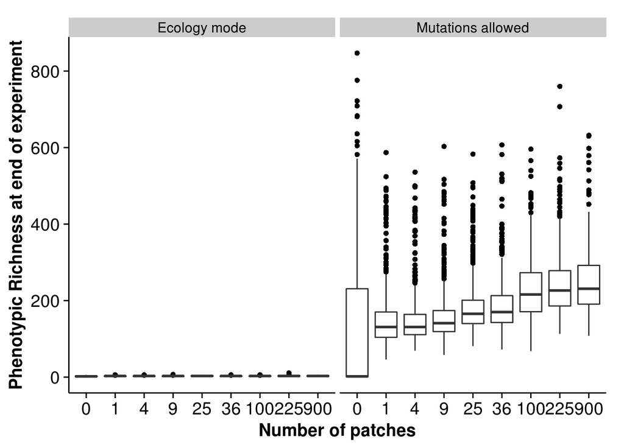

```r
cons.data$Ecology <- as.character(cons.data$Ecology)
cons.data$Ecology <- replace(cons.data$Ecology, which(cons.data$Ecology == "N"), "Mutations allowed")
cons.data$Ecology <- replace(cons.data$Ecology, which(cons.data$Ecology == "Y"), "Ecology mode")
cons.data$Ecology <- as.factor(cons.data$Ecology)
ggplot(data=cons.data, aes(x=as.factor(Patches), group=Patches)) + geom_boxplot(aes(y=Unique.Phenotype.Count)) + facet_wrap(~Ecology) + scale_x_discrete("Number of patches") + scale_y_continuous("Phenotypic Richness at end of experiment")
```

Stats I want to include in the paper:

```r
summary(lm(Unique.Phenotype.Count ~ Patches, data=subset(eco.cons.data, Patches > 0), na.action=na.omit, model=T))
```

```
##
## Call:
## lm(formula = Unique.Phenotype.Count ~ Patches, data = subset(eco.cons.data,
##     Patches > 0), na.action = na.omit, model = T)
##
## Residuals:
##     Min      1Q  Median      3Q     Max
## -1.9320 -0.8056  0.1835  0.1978  8.1655
##
## Coefficients:
##              Estimate Std. Error t value Pr(>|t|)
## (Intercept) 2.802e+00  1.994e-02 140.551   <2e-16 ***
## Patches     1.444e-04  6.036e-05   2.392   0.0168 *
## ---
## Signif. codes:  0 '***' 0.001 '**' 0.01 '*' 0.05 '.' 0.1 ' ' 1
##
## Residual standard error: 1.098 on 3998 degrees of freedom
## Multiple R-squared:  0.001429,   Adjusted R-squared:  0.001179
## F-statistic: 5.722 on 1 and 3998 DF,  p-value: 0.0168
```

```r
#Check assumptions
#plot(lm(Unique.Phenotype.Count ~ Patches, data=eco.cons.data, na.action=na.omit, model=T))
#Well that sure violates normalacy
summary(lm(log(Unique.Phenotype.Count) ~ log(Patches), data=subset(eco.cons.data, Patches > 0), na.action=na.omit, model=T))
```

```
##
## Call:
## lm(formula = log(Unique.Phenotype.Count) ~ log(Patches), data = subset(eco.cons.data,
##     Patches > 0), na.action = na.omit, model = T)
##
## Residuals:
##     Min      1Q  Median      3Q     Max
## -0.9850 -0.2619  0.1320  0.1704  1.4245
##
## Coefficients:
##              Estimate Std. Error t value Pr(>|t|)
## (Intercept)  0.928173   0.012916  71.861   <2e-16 ***
## log(Patches) 0.008352   0.003245   2.574   0.0101 *
## ---
## Signif. codes:  0 '***' 0.001 '**' 0.01 '*' 0.05 '.' 0.1 ' ' 1
##
## Residual standard error: 0.4244 on 3998 degrees of freedom
## Multiple R-squared:  0.001654,   Adjusted R-squared:  0.001405
## F-statistic: 6.625 on 1 and 3998 DF,  p-value: 0.01009
```

```r
#plot(lm(log(Unique.Phenotype.Count) ~ log(Patches), data=subset(eco.cons.data, Patches > 0), na.action=na.omit, model=T))
#Better...
#Oh shoot, we're violating independence anyway. Bring on the mixed models!
data <- subset(eco.cons.data, Patches > 0)
data$Initial.Pop <- as.factor(data$Initial.Pop)

eco_patch_number <- lmer(log(Unique.Phenotype.Count) ~ log(Patches) + (1|Initial.Pop), data=data, REML=FALSE)
eco_patch_number_null <- lmer(log(Unique.Phenotype.Count) ~ 1 + (1|Initial.Pop), data=data, REML=FALSE)
anova(eco_patch_number_null, eco_patch_number)
```

```
## Data: data
## Models:
## eco_patch_number_null: log(Unique.Phenotype.Count) ~ 1 + (1 | Initial.Pop)
## eco_patch_number: log(Unique.Phenotype.Count) ~ log(Patches) + (1 | Initial.Pop)
##                       Df     AIC     BIC logLik deviance  Chisq Chi Df
## eco_patch_number_null  3 -775.09 -756.20 390.54  -781.09
## eco_patch_number       4 -798.38 -773.21 403.19  -806.38 25.298      1
##                       Pr(>Chisq)
## eco_patch_number_null
## eco_patch_number       4.912e-07 ***
## ---
## Signif. codes:  0 '***' 0.001 '**' 0.01 '*' 0.05 '.' 0.1 ' ' 1
```

```r
summary(eco_patch_number)
```

```
## Linear mixed model fit by maximum likelihood  ['lmerMod']
## Formula: log(Unique.Phenotype.Count) ~ log(Patches) + (1 | Initial.Pop)
##    Data: data
##
##      AIC      BIC   logLik deviance df.resid
##   -798.4   -773.2    403.2   -806.4     3996
##
## Scaled residuals:
##     Min      1Q  Median      3Q     Max
## -2.4291 -0.4562 -0.1607  0.4261  7.4707
##
## Random effects:
##  Groups      Name        Variance Std.Dev.
##  Initial.Pop (Intercept) 0.13303  0.3647
##  Residual                0.04703  0.2169
## Number of obs: 4000, groups:  Initial.Pop, 10
##
## Fixed effects:
##              Estimate Std. Error t value
## (Intercept)  0.928173   0.115528   8.034
## log(Patches) 0.008352   0.001658   5.038
##
## Correlation of Fixed Effects:
##             (Intr)
## log(Patchs) -0.049
```

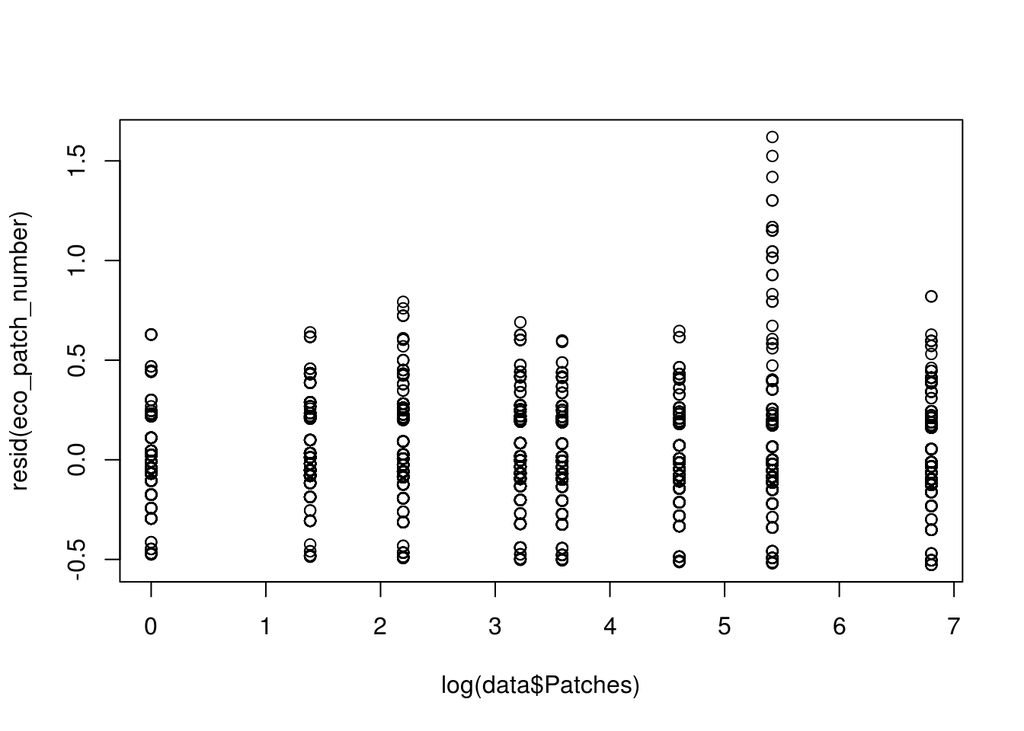

```r
plot(resid(eco_patch_number) ~ log(data$Patches))
```

Well, that’s a tiny but significant positive effect.

```r
data <- subset(evo.cons.data, Patches > 0)
data$Initial.Pop <- as.factor(data$Initial.Pop)

evo_patch_number <- lmer(log(Unique.Phenotype.Count) ~ log(Patches) + (1|Initial.Pop), data=data, REML=FALSE)
evo_patch_number_null <- lmer(log(Unique.Phenotype.Count) ~ 1 + (1|Initial.Pop), data=data, REML=FALSE)
anova(evo_patch_number_null, evo_patch_number)
```

```
## Data: data
## Models:
## evo_patch_number_null: log(Unique.Phenotype.Count) ~ 1 + (1 | Initial.Pop)
## evo_patch_number: log(Unique.Phenotype.Count) ~ log(Patches) + (1 | Initial.Pop)
##                       Df    AIC    BIC  logLik deviance  Chisq Chi Df
## evo_patch_number_null  3 3905.3 3924.2 -1949.7   3899.3
## evo_patch_number       4 2734.8 2759.9 -1363.4   2726.8 1172.6      1
##                       Pr(>Chisq)
## evo_patch_number_null
## evo_patch_number       < 2.2e-16 ***
## ---
## Signif. codes:  0 '***' 0.001 '**' 0.01 '*' 0.05 '.' 0.1 ' ' 1
```

```r
summary(evo_patch_number)
```

```
## Linear mixed model fit by maximum likelihood  ['lmerMod']
## Formula: log(Unique.Phenotype.Count) ~ log(Patches) + (1 | Initial.Pop)
##    Data: data
##
##      AIC      BIC   logLik deviance df.resid
##   2734.8   2759.9  -1363.4   2726.8     3996
##
## Scaled residuals:
##     Min      1Q  Median      3Q     Max
## -3.2877 -0.6598 -0.1157  0.5711  4.7458
##
## Random effects:
##  Groups      Name        Variance Std.Dev.
##  Initial.Pop (Intercept) 0.009414 0.09703
##  Residual                0.114751 0.33875
## Number of obs: 4000, groups:  Initial.Pop, 10
##
## Fixed effects:
##              Estimate Std. Error t value
## (Intercept)   4.86225    0.03237  150.22
## log(Patches)  0.09561    0.00259   36.92
##
## Correlation of Fixed Effects:
##             (Intr)
## log(Patchs) -0.272
```

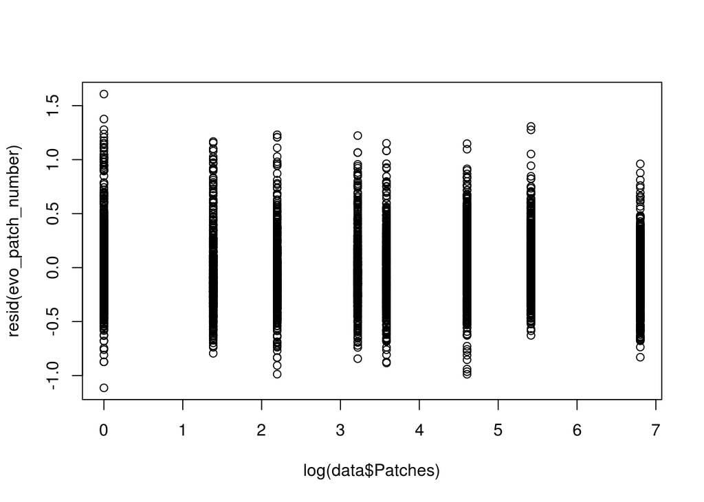

```r
plot(resid(evo_patch_number) ~ log(data$Patches))
```

Much larger effect.

```r
data <- subset(cons.data, Patches > 0)
data$Initial.Pop <- as.factor(data$Initial.Pop)

evo_effect <- lmer(Unique.Phenotype.Count ~ Ecology + (1|Initial.Pop), data=data, REML=FALSE)
evo_effect_null <- lmer(Unique.Phenotype.Count ~ 1 + (1|Initial.Pop), data=data, REML=FALSE)
anova(evo_effect_null, evo_effect)
```

```
## Data: data
## Models:
## evo_effect_null: Unique.Phenotype.Count ~ 1 + (1 | Initial.Pop)
## evo_effect: Unique.Phenotype.Count ~ Ecology + (1 | Initial.Pop)
##                 Df   AIC   BIC logLik deviance Chisq Chi Df Pr(>Chisq)
## evo_effect_null  3 98415 98436 -49205    98409
## evo_effect       4 88295 88323 -44143    88287 10123      1  < 2.2e-16 ***
## ---
## Signif. codes:  0 '***' 0.001 '**' 0.01 '*' 0.05 '.' 0.1 ' ' 1
```

```r
summary(evo_effect)
```

```
## Linear mixed model fit by maximum likelihood  ['lmerMod']
## Formula: Unique.Phenotype.Count ~ Ecology + (1 | Initial.Pop)
##    Data: data
##
##      AIC      BIC   logLik deviance df.resid
##  88294.8  88322.8 -44143.4  88286.8     7996
##
## Scaled residuals:
##     Min      1Q  Median      3Q     Max
## -2.6082 -0.3528  0.0024  0.1613  9.4675
##
## Random effects:
##  Groups      Name        Variance Std.Dev.
##  Initial.Pop (Intercept)  104.2   10.21
##  Residual                3619.2   60.16
## Number of obs: 8000, groups:  Initial.Pop, 10
##
## Fixed effects:
##                          Estimate Std. Error t value
## (Intercept)                 2.826      3.365    0.84
## EcologyMutations allowed  192.009      1.345  142.74
##
## Correlation of Fixed Effects:
##             (Intr)
## EclgyMttnsa -0.200
```

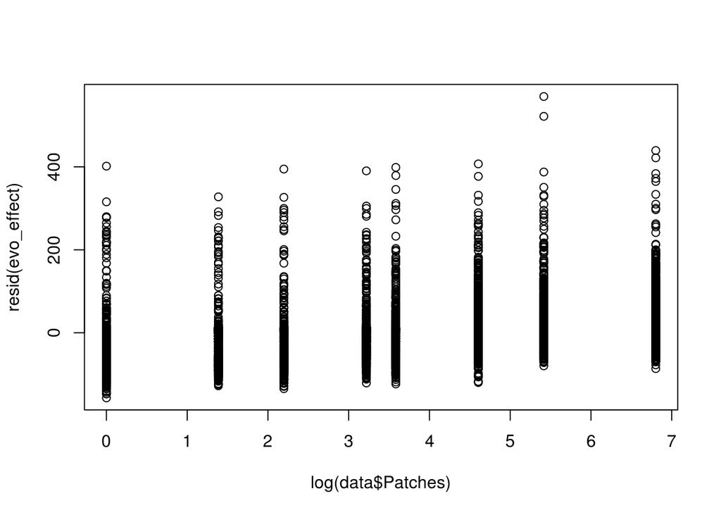

```r
plot(resid(evo_effect) ~ log(data$Patches))
```

```r
#Written in collaboration with Mike Wiser
######

# Thoughts on how to calculate birth probabilities.

# 1) Create matrix of cell connections. (3600 rows with 8 columns each)
# 2) Create function to implement birth method.
# 3) Create matrix that will serve as birth distribution map. (3600 by 3600)
# 4) For a given row, call birth method function, add 1 to the column representing the
#    birth location.
# 5) Iterate across each row, many times each.
# 6) Write .csv of this birth map.  It will be time intensive to make, but only needs to
#    be done once.
# 7) Create map of patches.  Label each patch differently, but same within patch.
# 8) Repeat 7 for each different patch configuration.
# 9) Using map, find proportion of births from each cell that are into
#  a) Dead region
#   b) Same patch as parent (if parent was in a patch)
#   c) Different patch from parent
# 10) Average 9 across all patch cells.


##############

# Step 1: Create matrix of cell connections:

world.x <- 60
world.y <- 60

number.cells <- world.x * world.y

connection.matrix <- matrix(nrow=number.cells, ncol=8)

# Establish non-torroidal connections:

for (i in 2:(world.y-1)) {
    for (j in 2:(world.x-1)) {

        current.cell <- ((i-1)*world.x + j)

        connection.1 <- current.cell - (world.y + 1)
        connection.2 <- current.cell - (world.y )
        connection.3 <- current.cell - (world.y - 1)
        connection.4 <- current.cell - 1
        connection.5 <- current.cell + 1
        connection.6 <- current.cell + (world.y - 1)
        connection.7 <- current.cell + (world.y )
        connection.8 <- current.cell + (world.y + 1)

        connection.matrix[current.cell, 1] <- connection.1
        connection.matrix[current.cell, 2] <- connection.2
        connection.matrix[current.cell, 3] <- connection.3
        connection.matrix[current.cell, 4] <- connection.4
        connection.matrix[current.cell, 5] <- connection.5
        connection.matrix[current.cell, 6] <- connection.6
        connection.matrix[current.cell, 7] <- connection.7
        connection.matrix[current.cell, 8] <- connection.8
        }
    }

# Left edge connections:

for (i in 2:(world.y-1)) {
    for (j in 1:1) {

        current.cell <- ((i-1)*world.x + j)

        connection.1 <- current.cell - 1
        connection.2 <- current.cell - (world.y )
        connection.3 <- current.cell - (world.y - 1)
        connection.4 <- current.cell + world.x - 1
        connection.5 <- current.cell + 1
        connection.6 <- current.cell + (world.y + world.x) - 1
        connection.7 <- current.cell + (world.y )
        connection.8 <- current.cell + (world.y + 1)

        connection.matrix[current.cell, 1] <- connection.1
        connection.matrix[current.cell, 2] <- connection.2
        connection.matrix[current.cell, 3] <- connection.3
        connection.matrix[current.cell, 4] <- connection.4
        connection.matrix[current.cell, 5] <- connection.5
        connection.matrix[current.cell, 6] <- connection.6
        connection.matrix[current.cell, 7] <- connection.7
        connection.matrix[current.cell, 8] <- connection.8
        }
    }

# Right edge connection:

for (i in 2:(world.y-1)) {
    for (j in world.x:world.x) {

        current.cell <- ((i-1)*world.x + j)

        connection.1 <- current.cell - (world.y + 1)
        connection.2 <- current.cell - (world.y )
        connection.3 <- current.cell - (world.y + world.x) + 1
        connection.4 <- current.cell - 1
        connection.5 <- current.cell - world.x + 1
        connection.6 <- current.cell + (world.y - 1)
        connection.7 <- current.cell + (world.y )
        connection.8 <- current.cell + 1

        connection.matrix[current.cell, 1] <- connection.1
        connection.matrix[current.cell, 2] <- connection.2
        connection.matrix[current.cell, 3] <- connection.3
        connection.matrix[current.cell, 4] <- connection.4
        connection.matrix[current.cell, 5] <- connection.5
        connection.matrix[current.cell, 6] <- connection.6
        connection.matrix[current.cell, 7] <- connection.7
        connection.matrix[current.cell, 8] <- connection.8
        }
    }

# Top edge connections:


for (i in 1:1) {
    for (j in 2:(world.x-1)) {

        current.cell <- ((i-1)*world.x + j)

        connection.1 <- ((world.y-1)*world.x) + j - 1
        connection.2 <- ((world.y-1)*world.x) + j
        connection.3 <- ((world.y-1)*world.x) + j + 1
        connection.4 <- current.cell - 1
        connection.5 <- current.cell + 1
        connection.6 <- current.cell + (world.y - 1)
        connection.7 <- current.cell + (world.y )
        connection.8 <- current.cell + (world.y + 1)

        connection.matrix[current.cell, 1] <- connection.1
        connection.matrix[current.cell, 2] <- connection.2
        connection.matrix[current.cell, 3] <- connection.3
        connection.matrix[current.cell, 4] <- connection.4
        connection.matrix[current.cell, 5] <- connection.5
        connection.matrix[current.cell, 6] <- connection.6
        connection.matrix[current.cell, 7] <- connection.7
        connection.matrix[current.cell, 8] <- connection.8
        }
    }


# Bottom edge connections:


for (i in world.y:world.y) {
    for (j in 2:(world.x-1)) {

        current.cell <- ((i-1)*world.x + j)

        connection.1 <- current.cell - (world.y + 1)
        connection.2 <- current.cell - (world.y )
        connection.3 <- current.cell - (world.y - 1)
        connection.4 <- current.cell - 1
        connection.5 <- current.cell + 1
        connection.6 <- j - 1
        connection.7 <- j
        connection.8 <- j + 1

        connection.matrix[current.cell, 1] <- connection.1
        connection.matrix[current.cell, 2] <- connection.2
        connection.matrix[current.cell, 3] <- connection.3
        connection.matrix[current.cell, 4] <- connection.4
        connection.matrix[current.cell, 5] <- connection.5
        connection.matrix[current.cell, 6] <- connection.6
        connection.matrix[current.cell, 7] <- connection.7
        connection.matrix[current.cell, 8] <- connection.8
        }
    }

# Upper left corner:

        current.cell <- 1

        connection.1 <- world.x*world.y
        connection.2 <- (world.y-1)*world.x + 1
        connection.3 <- (world.y-1)*world.x + 2
        connection.4 <- world.x
        connection.5 <- current.cell + 1
        connection.6 <- world.y + world.x
        connection.7 <- current.cell + (world.y )
        connection.8 <- current.cell + (world.y + 1)

        connection.matrix[current.cell, 1] <- connection.1
        connection.matrix[current.cell, 2] <- connection.2
        connection.matrix[current.cell, 3] <- connection.3
        connection.matrix[current.cell, 4] <- connection.4
        connection.matrix[current.cell, 5] <- connection.5
        connection.matrix[current.cell, 6] <- connection.6
        connection.matrix[current.cell, 7] <- connection.7
        connection.matrix[current.cell, 8] <- connection.8


# Upper right corner:

        current.cell <- world.x

        connection.1 <- world.x*world.y - 1
        connection.2 <- world.x*world.y
        connection.3 <- (world.y-1)*world.x + 1
        connection.4 <- current.cell - 1
        connection.5 <- 1
        connection.6 <- current.cell + (world.y - 1)
        connection.7 <- current.cell + (world.y )
        connection.8 <- current.cell + 1

        connection.matrix[current.cell, 1] <- connection.1
        connection.matrix[current.cell, 2] <- connection.2
        connection.matrix[current.cell, 3] <- connection.3
        connection.matrix[current.cell, 4] <- connection.4
        connection.matrix[current.cell, 5] <- connection.5
        connection.matrix[current.cell, 6] <- connection.6
        connection.matrix[current.cell, 7] <- connection.7
        connection.matrix[current.cell, 8] <- connection.8

# Lower left corner:

        current.cell <- (world.y-1)*world.x + 1

        connection.1 <- current.cell - 1
        connection.2 <- current.cell - (world.y )
        connection.3 <- current.cell - (world.y - 1)
        connection.4 <- world.x * world.y
        connection.5 <- current.cell + 1
        connection.6 <- world.x
        connection.7 <- 1
        connection.8 <- 2

        connection.matrix[current.cell, 1] <- connection.1
        connection.matrix[current.cell, 2] <- connection.2
        connection.matrix[current.cell, 3] <- connection.3
        connection.matrix[current.cell, 4] <- connection.4
        connection.matrix[current.cell, 5] <- connection.5
        connection.matrix[current.cell, 6] <- connection.6
        connection.matrix[current.cell, 7] <- connection.7
        connection.matrix[current.cell, 8] <- connection.8

# Lower right corner:

        current.cell <- world.x*world.y

        connection.1 <- current.cell - (world.y + 1)
        connection.2 <- current.cell - (world.y )
        connection.3 <- (world.y-2)*world.x + 1
        connection.4 <- current.cell - 1
        connection.5 <- (world.y-1)*world.x + 1
        connection.6 <- world.x - 1
        connection.7 <- world.x
        connection.8 <- 1

        connection.matrix[current.cell, 1] <- connection.1
        connection.matrix[current.cell, 2] <- connection.2
        connection.matrix[current.cell, 3] <- connection.3
        connection.matrix[current.cell, 4] <- connection.4
        connection.matrix[current.cell, 5] <- connection.5
        connection.matrix[current.cell, 6] <- connection.6
        connection.matrix[current.cell, 7] <- connection.7
        connection.matrix[current.cell, 8] <- connection.8

################

# We think a given cell may be listed as connected to itself.  Let's add a 9th
# column that is the given cell too.

own.cell<-matrix(nrow=number.cells, ncol=1)

for(i in 1:number.cells) {
    own.cell[i, 1] <- i
    }

connection.matrix <- cbind(own.cell, connection.matrix)

################

# Step 2: Create function of birth method.



# Function to pick connection cell:

pick.cell <- function(current.cell) {

    new.cell <- connection.matrix[current.cell, sample(1:9, 1)]

    return(new.cell)

    }

# Create map of cells into which organisms are born

birth.map <- matrix(nrow=number.cells, ncol=number.cells)

# Initialize birth.map to 0s

for (i in 1:number.cells) {
    for (j in 1:number.cells) {
        birth.map[j, i] <- 0
        }
    }

for (n in 1:100) {

    for (m in 1:number.cells) {

        # Draw number from Poisson distribution:

        poisson.draw <- rpois(n=1, lambda=1)

        current.cell <- m

        number.loops <- poisson.draw
        new.cell <- current.cell
        while (number.loops + 1 > 0) {
            new.cell <- pick.cell(new.cell)
            number.loops <- number.loops - 1
            }

        birth.map[m, new.cell] <- birth.map[m, new.cell] + 1

        }

    }


write.csv(birth.map, file="birth.map.csv")
```

Now we can load in the result of that simulation:

```r
birth.map <- read.csv("~/Downloads/birth.map.csv")
w <- as.matrix(birth.map[,2:3601]) #convert to matrix and cut off label row
w <- w/max(w) #normalize to [0, 1]. Note that we don't need to invert the distance matrix because these are probabilities of interaction between cells, not distances.
diag(w) <- 0 #autocorrelation doesn't go up because a cell is connected to itself
```

We’re going to look at the spatial autocorrelation of phylogenetic depth across the world. Phylogenetic depth measures how many mutations have occurred to a lineage over the course of a run of evolution. This is a good proxy for separating out clades and treating neutral mutants as appropriately similar. It is not perfect, though. Two organisms could have the same phylogenetic depth, but different phenotypes. Let’s start by looking at phylogenetic depth for all 10 initial populations. First, we need to genrate spatial phylogeneitc depth grids from Avida’s base output:

```python
#Python code, because the libraries I needed are in Python and not R

import avidaspatial #Python module I wrote
import glob

def load_detail_file(filename, world_dims):
    phylo_depth = 13
    number = 4
    cells = 17

    world = avidaspatial.utils.initialize_grid(world_dims, "-1")
    infile = open(filename)
    for line in infile:
        if line.strip().startswith("#"):
            continue
        sline = line.split()
        if len(sline) < 20:
            continue

        if int(sline[number]) == 0:
            continue

        depth = sline[phylo_depth]
        active_cells = [int(i) for i in sline[cells].split(",")]
        for cell in active_cells:
            world[cell // world_dims[1]][cell % world_dims[0]] = depth

    infile.close()
    return world

def write_new_grid(filename, world):
    outfile = open(filename, "w")
    for line in world:
        #print line
        outfile.write(",".join(line) + "\n")
    outfile.close()

#Make phylogenetic depth grid files for initial populations
for filename in glob.glob("/home/emily/hpcc/conservation/initials/initial_pop*/detail-100000.spop"):
    pop = filename.split("/")[-2].split("_")[-1]
    world =  load_detail_file(filename, (60,60))
    write_new_grid("phylo_depth_initial_"+pop, world)

#Make phylogenetic depth grid files for end of experiments
for filename in glob.glob("/home/emily/hpcc/conservation/round_2_results/*/data/detail-100000.spop"):
    root = "/".join(filename.split("/")[:-1])
    world =  load_detail_file(filename, (60,60))
    write_new_grid(root+"/phylo_depth_grid", world)
```

Now we can read it in:

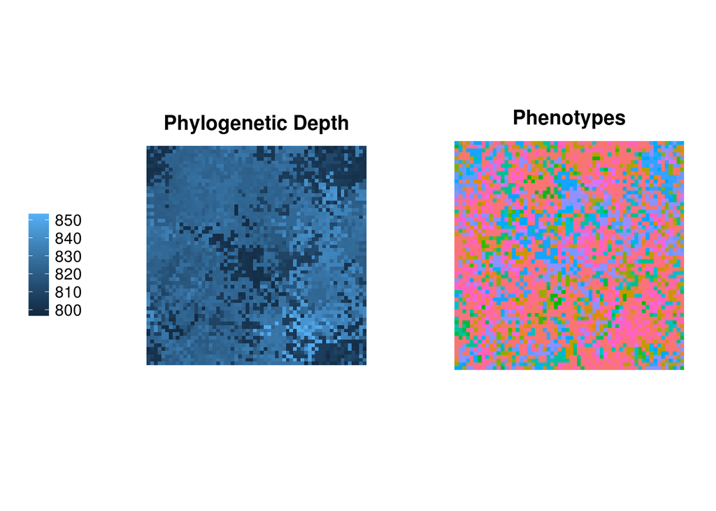

```r
phylo_depth_pop1 <- as.matrix(read.csv("/media/emily/hdd/conservation/phylo_depth_initial_1", header=FALSE, na.strings=c(-1)))
phylo_depth_pop2 <- as.matrix(read.csv("/media/emily/hdd/conservation/phylo_depth_initial_2", header=FALSE, na.strings=c(-1)))
phylo_depth_pop3 <- as.matrix(read.csv("/media/emily/hdd/conservation/phylo_depth_initial_3", header=FALSE, na.strings=c(-1)))
phylo_depth_pop4 <- as.matrix(read.csv("/media/emily/hdd/conservation/phylo_depth_initial_4", header=FALSE, na.strings=c(-1)))
phylo_depth_pop5 <- as.matrix(read.csv("/media/emily/hdd/conservation/phylo_depth_initial_5", header=FALSE, na.strings=c(-1)))
phylo_depth_pop6 <- as.matrix(read.csv("/media/emily/hdd/conservation/phylo_depth_initial_6", header=FALSE, na.strings=c(-1)))
phylo_depth_pop7 <- as.matrix(read.csv("/media/emily/hdd/conservation/phylo_depth_initial_7", header=FALSE, na.strings=c(-1)))
phylo_depth_pop8 <- as.matrix(read.csv("/media/emily/hdd/conservation/phylo_depth_initial_8", header=FALSE, na.strings=c(-1)))
phylo_depth_pop9 <- as.matrix(read.csv("/media/emily/hdd/conservation/phylo_depth_initial_9", header=FALSE, na.strings=c(-1)))
phylo_depth_pop10 <- as.matrix(read.csv("/media/emily/hdd/conservation/phylo_depth_initial_10", header=FALSE, na.strings=c(-1)))

colnames(phylo_depth_pop1) <- 1:60
colnames(phylo_depth_pop2) <- 1:60
colnames(phylo_depth_pop3) <- 1:60
colnames(phylo_depth_pop4) <- 1:60
colnames(phylo_depth_pop5) <- 1:60
colnames(phylo_depth_pop6) <- 1:60
colnames(phylo_depth_pop7) <- 1:60
colnames(phylo_depth_pop8) <- 1:60
colnames(phylo_depth_pop9) <- 1:60
colnames(phylo_depth_pop10) <- 1:60

phenotypes_pop1 <- as.matrix(read.csv("/home/emily/hpcc/conservation/initials/initial_pop_1/grid_task.100000.dat", header=FALSE, sep = " ", na.strings=c(-1))[, 1:60])
phenotypes_pop2 <- as.matrix(read.csv("/home/emily/hpcc/conservation/initials/initial_pop_2/grid_task.100000.dat", header=FALSE, sep = " ", na.strings=c(-1))[, 1:60])
phenotypes_pop3 <- as.matrix(read.csv("/home/emily/hpcc/conservation/initials/initial_pop_3/grid_task.100000.dat", header=FALSE, sep = " ", na.strings=c(-1))[, 1:60])
phenotypes_pop4 <- as.matrix(read.csv("/home/emily/hpcc/conservation/initials/initial_pop_4/grid_task.100000.dat", header=FALSE, sep = " ", na.strings=c(-1))[, 1:60])
phenotypes_pop5 <- as.matrix(read.csv("/home/emily/hpcc/conservation/initials/initial_pop_5/grid_task.100000.dat", header=FALSE, sep = " ", na.strings=c(-1))[, 1:60])
phenotypes_pop6 <- as.matrix(read.csv("/home/emily/hpcc/conservation/initials/initial_pop_6/grid_task.100000.dat", header=FALSE, sep = " ", na.strings=c(-1))[, 1:60])
phenotypes_pop7 <- as.matrix(read.csv("/home/emily/hpcc/conservation/initials/initial_pop_7/grid_task.100000.dat", header=FALSE, sep = " ", na.strings=c(-1))[, 1:60])
phenotypes_pop8 <- as.matrix(read.csv("/home/emily/hpcc/conservation/initials/initial_pop_8/grid_task.100000.dat", header=FALSE, sep = " ", na.strings=c(-1))[, 1:60])
phenotypes_pop9 <- as.matrix(read.csv("/home/emily/hpcc/conservation/initials/initial_pop_9/grid_task.100000.dat", header=FALSE, sep = " ", na.strings=c(-1))[, 1:60])
phenotypes_pop10 <- as.matrix(read.csv("/home/emily/hpcc/conservation/initials/initial_pop_10/grid_task.100000.dat", header=FALSE, sep = " ", na.strings=c(-1))[, 1:60])

colnames(phenotypes_pop1) <- 1:60
colnames(phenotypes_pop2) <- 1:60
colnames(phenotypes_pop3) <- 1:60
colnames(phenotypes_pop4) <- 1:60
colnames(phenotypes_pop5) <- 1:60
colnames(phenotypes_pop6) <- 1:60
colnames(phenotypes_pop7) <- 1:60
colnames(phenotypes_pop8) <- 1:60
colnames(phenotypes_pop9) <- 1:60
colnames(phenotypes_pop10) <- 1:60


phylo_depths <- list(phylo_depth_pop1, phylo_depth_pop2, phylo_depth_pop3, phylo_depth_pop4, phylo_depth_pop5, phylo_depth_pop6, phylo_depth_pop7, phylo_depth_pop8, phylo_depth_pop9, phylo_depth_pop10)


comparison_plots <- function(phylo, pheno){
  phylo_plot <- ggplot(data=melt(phylo), aes(Var1, Var2, fill=value, na.rm=TRUE)) + geom_tile()+ theme(legend.position="left", panel.grid.major = element_blank(), #removes the grid associated with major tick marks
    panel.grid.minor = element_blank(), #removes the grid associated with minor tick marks
    panel.background = element_blank(), #removes the grey panel in the background
    axis.line = element_blank(), axis.ticks = element_blank(), axis.text.x = element_blank(), axis.text.y = element_blank()) + coord_fixed(ratio=1) + scale_fill_continuous("", na.value = "grey") + scale_x_continuous("") + scale_y_continuous("") + ggtitle("Phylogenetic Depth")

  pheno_plot <- ggplot(data=melt(pheno), aes(Var1, Var2, fill=as.factor(value), na.rm=TRUE)) + geom_tile() + theme(legend.position="bottom", panel.grid.major = element_blank(), #removes the grid associated with major tick marks
    panel.grid.minor = element_blank(), #removes the grid associated with minor tick marks
    panel.background = element_blank(), #removes the grey panel in the background
    axis.line = element_blank(), axis.ticks = element_blank(), axis.text.x = element_blank(), axis.text.y = element_blank()) + scale_fill_discrete(na.value = "grey", guide="none") + coord_fixed(ratio=1)+ scale_x_continuous("") + scale_y_continuous("") + ggtitle("Phenotypes")

  phylo_plot
  pheno_plot
  #ggdraw(phylo_plot) + draw_plot(pheno_plot, 0, 0, 1, .5)
  plot_grid(phylo_plot, pheno_plot, nrow = 1, ncol = 2, rel_widths =c(1.25, 1) )
}

comparison_plots(phylo_depth_pop1, phenotypes_pop1)
```

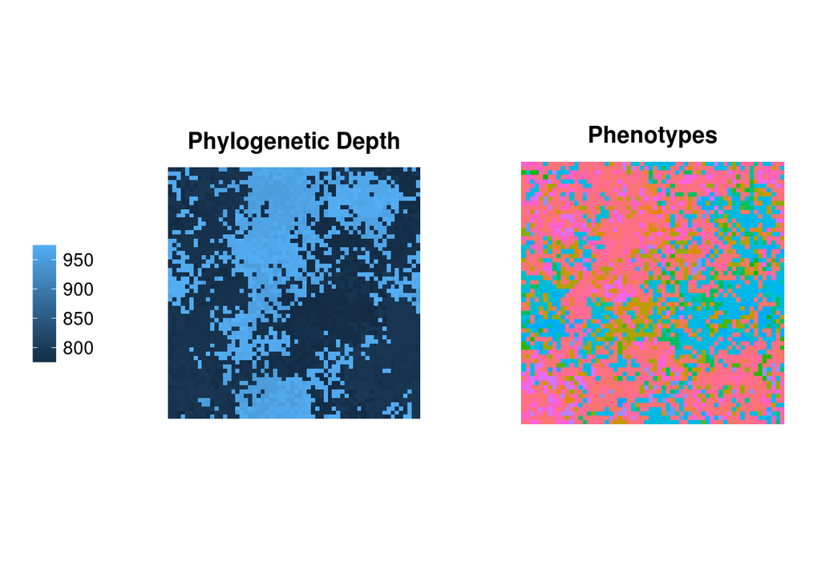

```r
comparison_plots(phylo_depth_pop2, phenotypes_pop2)
```

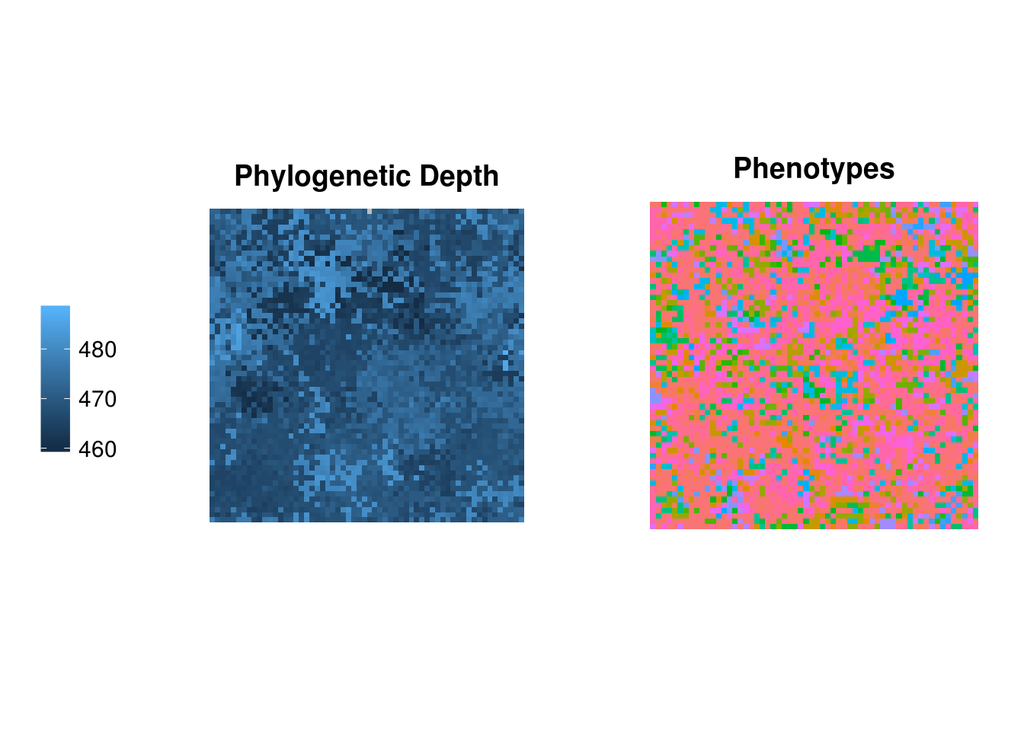

```r
comparison_plots(phylo_depth_pop3, phenotypes_pop3)
```

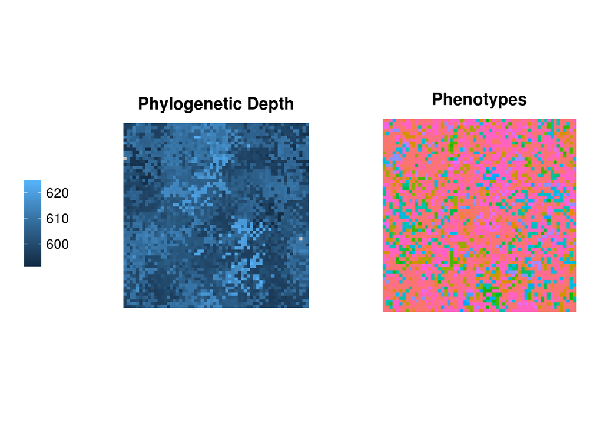

```r
comparison_plots(phylo_depth_pop4, phenotypes_pop4)
```

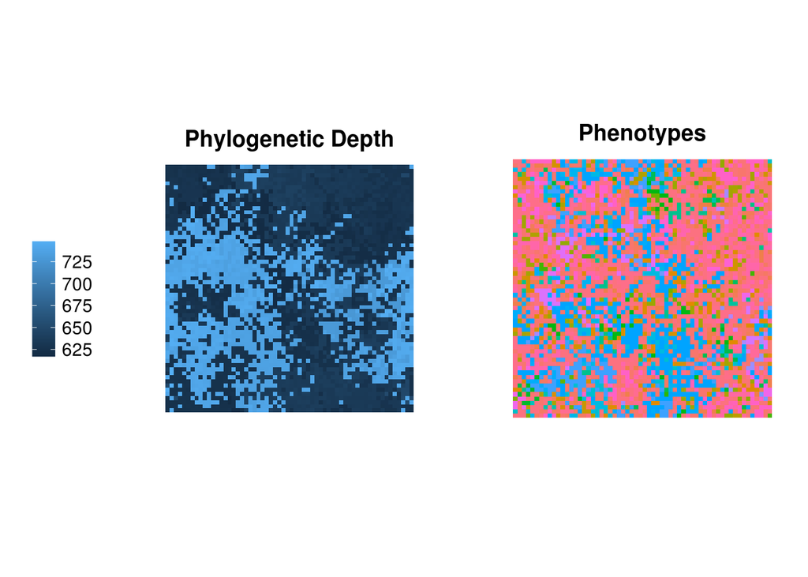

```r
comparison_plots(phylo_depth_pop5, phenotypes_pop5)
```

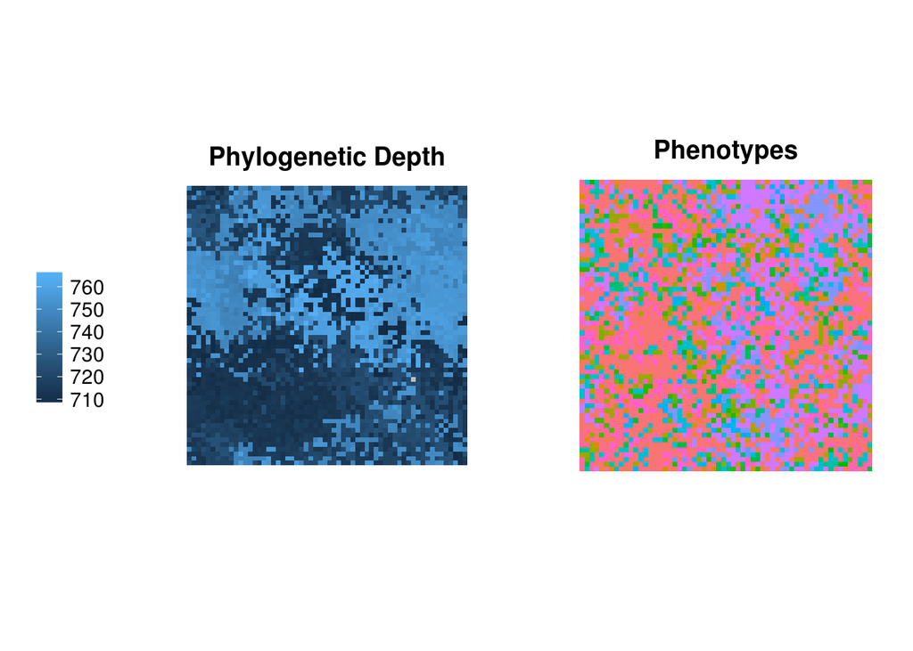

```r
comparison_plots(phylo_depth_pop6, phenotypes_pop6)
```

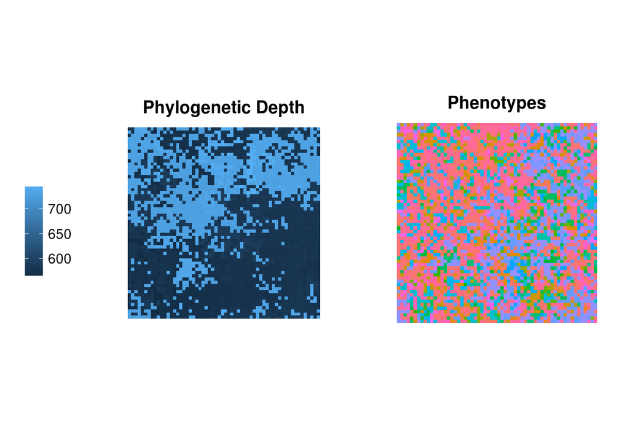

```r
comparison_plots(phylo_depth_pop7, phenotypes_pop7)
```

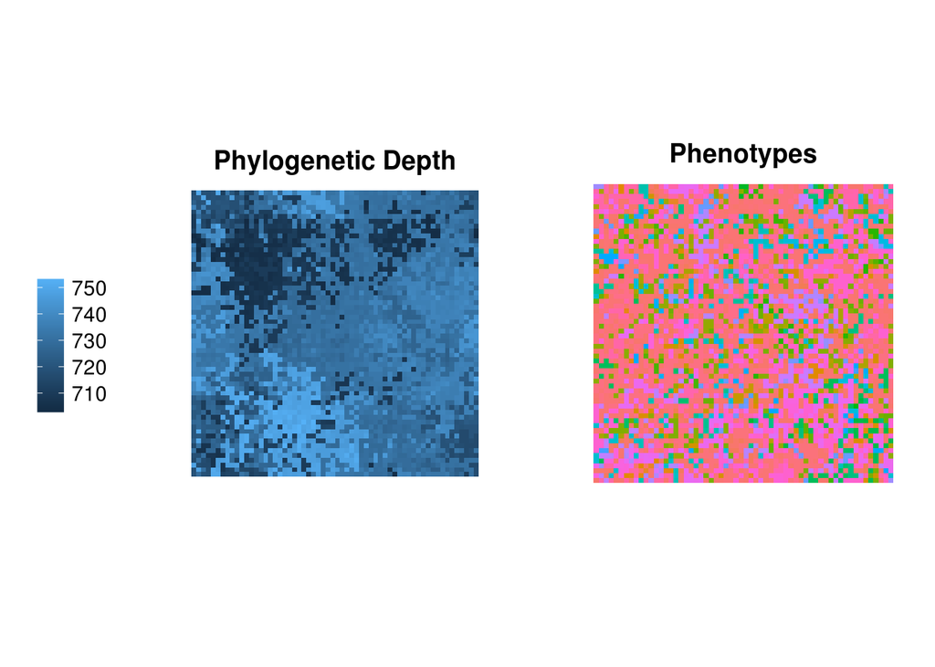

```r
comparison_plots(phylo_depth_pop8, phenotypes_pop8)
```

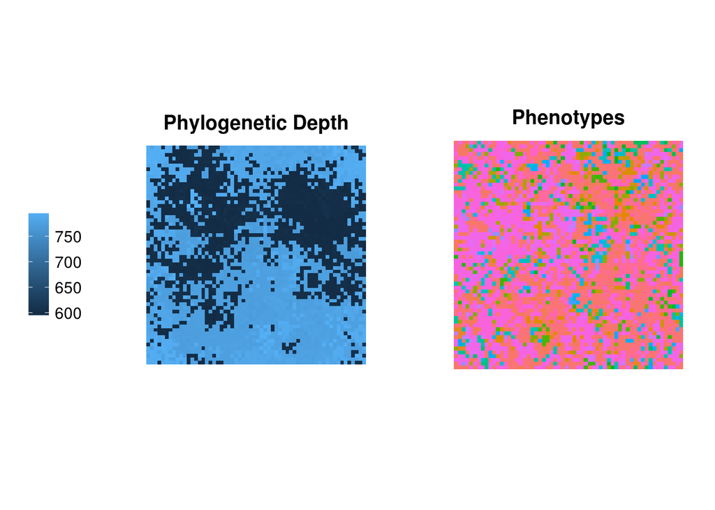

```r
comparison_plots(phylo_depth_pop9, phenotypes_pop9)
```

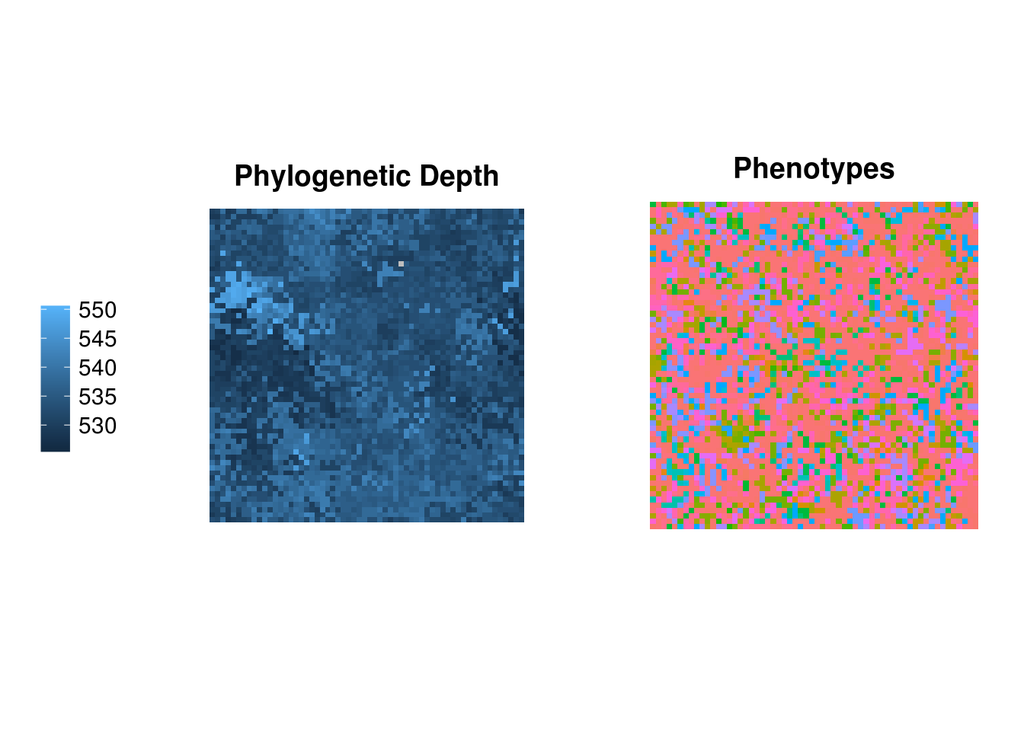

```r
comparison_plots(phylo_depth_pop10, phenotypes_pop10)
```

```r
initial_morans <- lapply(phylo_depths, function(mat){Moran.I(as.vector(t(mat)), w, na.rm=TRUE)})
initial_morans_df <- NULL

for (i in 1:10){
  initial_morans_df <- rbind(initial_morans_df, unlist(initial_morans[[i]]))
}

initial_morans_df <- as.data.frame(initial_morans_df)

initial_morans_df$result <- initial_morans_df$observed - initial_morans_df$expected
```

Let’s compare phylogenetic depth before evolution to afterwards. There isn’t really a good way to aggregate this across runs, so here’s a representative example:

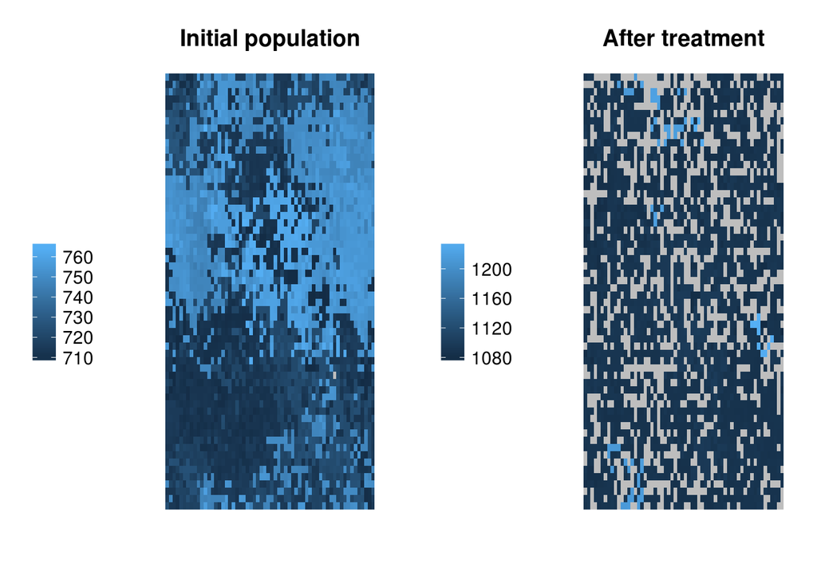

```r
phylo_after <- as.matrix(read.csv("/home/emily/hpcc/conservation/round_2_results/225_patches_2_cells_200_killed-pop6_13353/data/phylo_depth_grid", header=FALSE, sep=",", na.strings=c(-1, "NA"))[,1:60])
colnames(phylo_after) <- 1:60

before <- ggplot(data=melt(phylo_depth_pop6), aes(Var1, Var2, fill=value, na.rm=TRUE)) + geom_tile()+ theme(legend.position="left", panel.grid.major = element_blank(), #removes the grid associated with major tick marks
    panel.grid.minor = element_blank(), #removes the grid associated with minor tick marks
    panel.background = element_blank(), #removes the grey panel in the background
    axis.line = element_blank(), axis.ticks = element_blank(), axis.text.x = element_blank(), axis.text.y = element_blank())  + scale_fill_continuous("", na.value = "grey") + scale_x_continuous("") + scale_y_continuous("") + ggtitle("Initial population")

after <- ggplot(data=melt(phylo_after), aes(Var1, Var2, fill=value, na.rm=TRUE)) + geom_tile()+ theme(legend.position="left", panel.grid.major = element_blank(), #removes the grid associated with major tick marks
    panel.grid.minor = element_blank(), #removes the grid associated with minor tick marks
    panel.background = element_blank(), #removes the grey panel in the background
    axis.line = element_blank(), axis.ticks = element_blank(), axis.text.x = element_blank(), axis.text.y = element_blank()) + scale_fill_continuous("", na.value = "grey") + scale_x_continuous("") + scale_y_continuous("") + ggtitle("After treatment")

multiplot(before, after, cols=2)
```

This isn’t a super useful visualization. We can see that a lot of cells are unoccupied, and that phylogenetic depth has increased (because evolution continued), but there isn’t a clear correspondance between the two images. This will be a lot more useful when examining images from the ecology mode control:

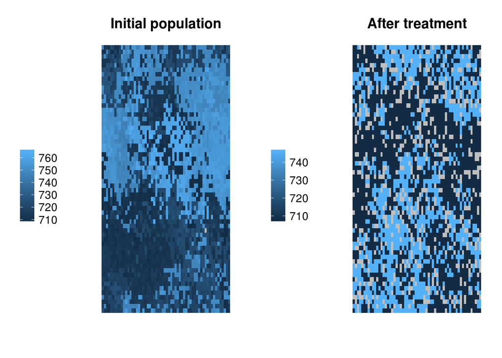

```r
phylo_after_eco <- as.matrix(read.csv("/home/emily/hpcc/conservation/round_2_results/225_patches_2_cells_200_killed_ecology-pop6_18353/data/phylo_depth_grid", header=FALSE, sep=",", na.strings=c(-1, "NA"))[,1:60])
colnames(phylo_after_eco) <- 1:60

after <- ggplot(data=melt(phylo_after_eco), aes(Var1, Var2, fill=value, na.rm=TRUE)) + geom_tile()+ theme(legend.position="left", panel.grid.major = element_blank(), #removes the grid associated with major tick marks
    panel.grid.minor = element_blank(), #removes the grid associated with minor tick marks
    panel.background = element_blank(), #removes the grey panel in the background
    axis.line = element_blank(), axis.ticks = element_blank(), axis.text.x = element_blank(), axis.text.y = element_blank()) + scale_fill_continuous("", na.value = "grey") + scale_x_continuous("") + scale_y_continuous("") + ggtitle("After treatment")

multiplot(before, after, cols=2)
```

This image actually tells us something. We can see that in general there is much higher contrast between regions in this image. That’s likely the result of netural and lower fitness mutants drifting/being competed out. We can also see that the range of phylogenetic depths present has decreased. This suggests that we lost the clade that was most different from the ancestor.

```
## variog: computing omnidirectional variogram
```

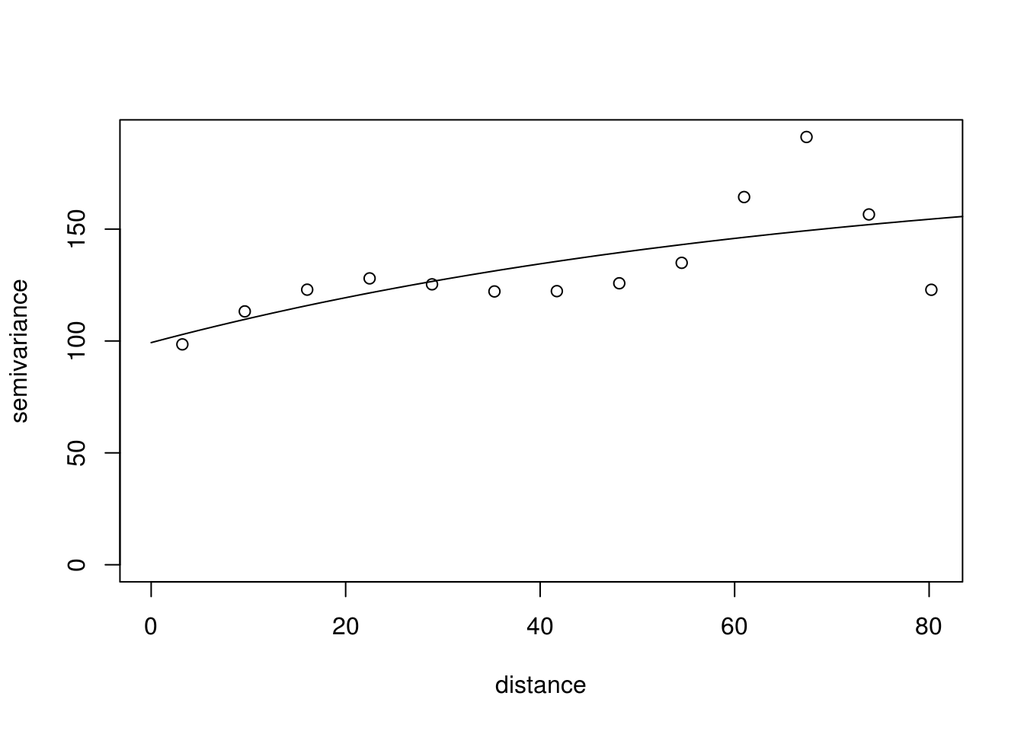

```
## variofit: covariance model used is exponential
## variofit: weights used: equal
## variofit: minimisation function used: nls
```

```r
coords = matrix(0, byrow = TRUE, nrow=3600, ncol=2)
for (i in 1:60){
  for (j in 1:60){
    coords[(i-1)*60+j, 1] <- i
    coords[(i-1)*60+j, 2] <- j
  }
}

plot_variogram <- function(mat){
  v = variog(coords = coords, data=as.vector(mat))
  plot(v)
  v_fit <-variofit(v, ini.cov.pars=c(v$v[8], 20), cov.model="exponential", minimisation.function="nls", weights="equal", na.rm=TRUE)
  lines(v_fit)
}

plot_variogram(phylo_depth_pop1)
```

```
## variog: computing omnidirectional variogram
```

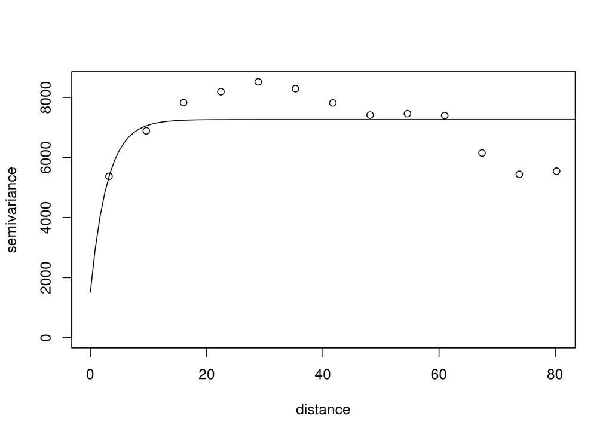

```
## variofit: covariance model used is exponential
## variofit: weights used: equal
## variofit: minimisation function used: nls
```

```r
plot_variogram(phylo_depth_pop2)
```

```r
#etc. Further variograms result in errors, due to werid behavior induced by toroidal grid
```

Now let’s extract information about species-area relationships. This will take a long time, so I ran it on the HPCC:

```r
get_patch_diversity <- function(mat, n, size){
  alpha_shannon_entropy <- vector(mode = "numeric", length=n)
  alpha_richness <- vector(mode = "numeric", length=n)
  patch_size <- rep(c(size), n)
  result <- data.frame(alpha_shannon_entropy, alpha_richness, patch_size)
  #result
  sum_mat <- c()
  for (i in 0:(n-1)){
    x <- ((i %% sqrt(n))*size*2) + 1
    y <- ((i %/% sqrt(n))*size*2) + 1
    patch <- mat[x:(x+size-1), y:(y+size-1)]
    result[i+1, 2] <- length(unique(as.vector(patch)))
    result[i+1, 1] <- entropy(table(patch), unit="log2")
    sum_mat <- c(sum_mat, patch)
  }
  result$gamma_richness <- length(unique(as.vector(mat)))
  result$gamma_shannon_entropy <- entropy(table(mat), unit="log2")
  result$captured_richness <- length(unique(as.vector(sum_mat)))
  result$captured_shannon_entropy <- entropy(table(sum_mat), unit="log2")
  return(result)
}

dirs <- list.dirs(path = "/home/emily/hpcc/conservation/round_2_results", recursive=FALSE)

sar_data <- NULL
per_run_analysis <- NULL
#colnames(sar_data) <- c("seed", "killed", "ecology", "richness", "shannon_entropy", "patch_size")


for (d in sample(dirs, 100)){
  start_file <- paste(d, "data", "grid_task.0.dat", sep="/")
  end_file <- paste(d, "data", "grid_task.100000.dat", sep="/")
  phylo_file <- paste(d, "data", "phylo_depth_grid", sep="/")
  print(d)
  if (file.exists(start_file) & file.exists(end_file)){
    condition  <- tail(unlist(strsplit(d, split = "/", fixed = T)), n=1)
    killed <- as.numeric(unlist(regmatches(condition, gregexpr('\\d+(?=_killed)', condition , perl=T))))

    reserves <- FALSE

    patches <- 1
    if (as.numeric(unlist(gregexpr('patch', condition , perl=T)))>0) {
                patches <- as.numeric(unlist(regmatches(condition, gregexpr('\\d+(?=_patch)', condition , perl=T))))
        reserves <- TRUE
    }

    cells <- 60
    if (as.numeric(unlist(gregexpr('cell', condition , perl=T)))>0) {
            cells <- as.numeric(unlist(regmatches(condition, gregexpr('\\d+(?=_cell)', condition , perl=T))))
    }

    ecology <- FALSE

    if (as.numeric(unlist(gregexpr('ecology', condition , perl=T)))>0) {
                ecology <- TRUE
        }

    full.string <- tail(unlist(strsplit(d, split = "/", fixed = T)), n=1)
    seed <- tail(unlist(strsplit(full.string, split = "_", fixed = T)), n=1)

    condition_end <- tail(unlist(strsplit(full.string, split = "-", fixed = T)), n=1)
        initial_pop <- head(unlist(strsplit(condition_end, split = "_", fixed = T)), n=1)


    start_mat <- as.matrix(read.csv(start_file, header=FALSE, sep = " ", na.strings=c(-1))[, 1:60])
    start <- get_patch_diversity(start_mat, patches, cells)
    start$update <- 0

    end_mat <- as.matrix(read.csv(end_file, header=FALSE, sep = " ", na.strings=c(-1))[, 1:60])
    end <- get_patch_diversity(end_mat, patches, cells)
    end$update <- 100000

    phylo_mat <- as.matrix(read.csv(phylo_file, header=FALSE, sep = ",", na.strings=c(-1))[, 1:60])

    data <- rbind(start, end)
    data$seed <- seed
    data$patches <- patches
    data$ecology <- ecology
    data$reserves <- reserves
    data$killed <- killed
    data$condition <- condition
    data$initial_pop <- initial_pop

    tmp <- data.frame(seed=c(seed))
    tmp$patches <- patches
    tmp$ecology <- ecology
    tmp$reserves <- reserves
    tmp$killed <- killed
    tmp$condition <- condition
    tmp$initial_pop <- initial_pop
    tmp$patch_size <- cells
    m <- Moran.I(replace(as.vector(t(end_mat)), is.na(as.vector(t(end_mat))), 0), w)
    tmp$end_moran <- m$observed - m$expected
    tmp$lost_phenotypes <- length(setdiff(as.vector(start_mat), as.vector(end_mat)))
    tmp$new_phenotypes <- length(setdiff(as.vector(end_mat), as.vector(start_mat)))
    sar_data <- rbind(sar_data, data)
    per_run_analysis <- rbind(per_run_analysis, tmp)
  }
}
```

Now we can load the data from the HPCC in:

```r
patch_data <- read.csv("patch_data.csv") #data on patches (multiple per run)
per_run_analysis <- read.csv("per_run_analysis.csv") #data on global dyamics (1 per run)

#Let's save out some subsets we'll use a lot
end_evolution_data <- subset(patch_data, update==100000 & reserves==TRUE & ecology==FALSE)
end_evolution_data$seed <- as.factor(end_evolution_data$seed)

end_ecology_data <- subset(patch_data, update==100000 & reserves==TRUE & ecology==TRUE)
end_ecology_data$seed <- as.factor(end_ecology_data$seed)

start_data <- subset(patch_data, update==0 & reserves==TRUE)
start_data$seed <- as.factor(start_data$seed)

end_data <- subset(patch_data, update==100000 & reserves==TRUE)
end_data$seed <- as.factor(end_data$seed)

end_data_per_run <- subset(per_run_analysis, reserves==TRUE)
end_data_per_run$seed <- as.factor(end_data_per_run$seed)

end_evolution_data_per_run <- subset(per_run_analysis, reserves==TRUE & ecology==FALSE)
end_evolution_data_per_run$seed <- as.factor(end_evolution_data_per_run$seed)

end_ecology_data_per_run <- subset(per_run_analysis, reserves==TRUE & ecology==TRUE)
end_ecology_data_per_run$seed <- as.factor(end_ecology_data_per_run$seed)
```

Let’s compare alpha diveristy with the amount of gamma diversity captured across patch sizes .

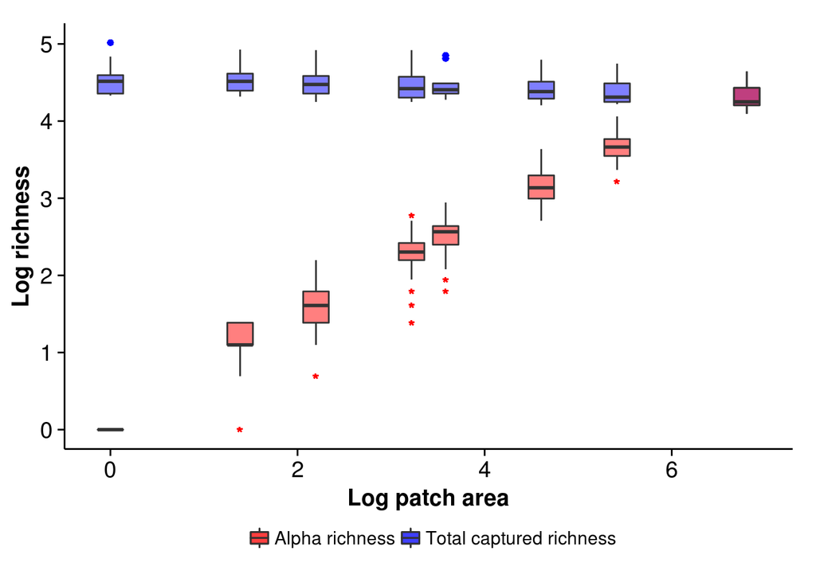

```r
ggplot(data=start_data, #Let's look at data from the initial populations
       aes(group=(patch_size^2), #patch_size variable is edge length
      x=log(patch_size^2))) +
  geom_boxplot(aes(y=log(captured_richness), fill="Total captured richness"), outlier.colour = "blue",
               outlier.size = 2, alpha=.5) +
  geom_boxplot(aes(y=log(alpha_richness), fill="Alpha richness"), outlier.colour = "red",
               outlier.shape = "*", outlier.size = 4, alpha=.5) +
  scale_x_continuous("Log patch area") + scale_y_continuous("Log richness") +
  scale_fill_manual("", values=c("red", "blue")) + theme(legend.position="bottom")
```

```r
summary(lm(data=start_data, log(alpha_richness) ~ log(patch_size^2)))
```

```
##
## Call:
## lm(formula = log(alpha_richness) ~ log(patch_size^2), data = start_data)
##
## Residuals:
##      Min       1Q   Median       3Q      Max
## -1.01090 -0.01326 -0.01326 -0.01326  0.60275
##
## Coefficients:
##                    Estimate Std. Error t value Pr(>|t|)
## (Intercept)       0.0132603  0.0001617   82.03   <2e-16 ***
## log(patch_size^2) 0.7196432  0.0001315 5471.49   <2e-16 ***
## ---
## Signif. codes:  0 '***' 0.001 '**' 0.01 '*' 0.05 '.' 0.1 ' ' 1
##
## Residual standard error: 0.1591 on 1299998 degrees of freedom
## Multiple R-squared:  0.9584, Adjusted R-squared:  0.9584
## F-statistic: 2.994e+07 on 1 and 1299998 DF,  p-value: < 2.2e-16
```

This data demonstrates the standard species-area relationship. log(patch area) and log(richness) increase linearly. However, the amount of richness captured across different patch sizes is relatively constant.

```r
summary(lm(data=start_data, log(captured_richness) ~ log(patch_size^2)))
```

```
##
## Call:
## lm(formula = log(captured_richness) ~ log(patch_size^2), data = start_data)
##
## Residuals:
##      Min       1Q   Median       3Q      Max
## -0.34236 -0.19338 -0.06107  0.04504  0.46720
##
## Coefficients:
##                     Estimate Std. Error  t value Pr(>|t|)
## (Intercept)        4.5500846  0.0002127 21391.15   <2e-16 ***
## log(patch_size^2) -0.0166675  0.0001731   -96.31   <2e-16 ***
## ---
## Signif. codes:  0 '***' 0.001 '**' 0.01 '*' 0.05 '.' 0.1 ' ' 1
##
## Residual standard error: 0.2093 on 1299998 degrees of freedom
## Multiple R-squared:  0.007084,   Adjusted R-squared:  0.007083
## F-statistic:  9275 on 1 and 1299998 DF,  p-value: < 2.2e-16
```

In fact there is a significant inverse relationship between patch size and captured richness. The effect size is small, and explains so little variance in captured richness that it’s probably not actually worth discussing. But just saying.

This suggests that we are indeed in the scenario described by Simberloff and Abele - because the smaller patches are spread across the environment, they are sampling from different species pools.

Let’s take a look at what happens after the treatment:

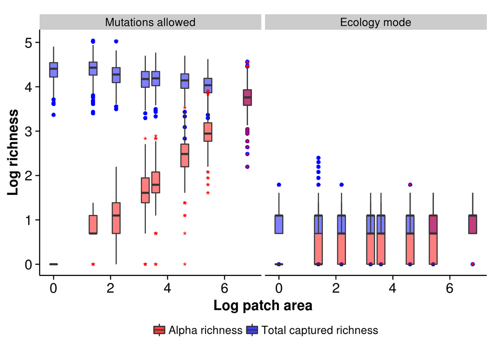

```r
ggplot(data=end_data,
       aes(group=(patch_size^2), #patch_size variable is edge length
      x=log(patch_size^2))) +
  geom_boxplot(aes(y=log(captured_richness), fill="Total captured richness"), outlier.colour = "blue",
               outlier.size = 2, alpha=.5) +
  geom_boxplot(aes(y=log(alpha_richness), fill="Alpha richness"), outlier.colour = "red",
               outlier.shape = "*", outlier.size = 4, alpha=.5) +
  scale_x_continuous("Log patch area") + scale_y_continuous("Log richness") +
  scale_fill_manual("", values=c("red", "blue")) + theme(legend.position="bottom") +
  facet_grid(~ecology, labeller=function(variable, value){
        for (i in 1:length(value)){
          if (value[i]){
            value[i] <-  "Ecology mode"
          } else {
            value[i] <- "Mutations allowed"
            }
        }
      return(value)
      })
```

Allowing evolution to proceed for 100,000 generations maintains the species area relationship.

```r
summary(lm(log(alpha_richness) ~ log(patch_size^2), data=end_evolution_data))
```

```
##
## Call:
## lm(formula = log(alpha_richness) ~ log(patch_size^2), data = end_evolution_data)
##
## Residuals:
##     Min      1Q  Median      3Q     Max
## -2.3654 -0.0061 -0.0061 -0.0061  1.1780
##
## Coefficients:
##                    Estimate Std. Error t value Pr(>|t|)
## (Intercept)       0.0060981  0.0003484    17.5   <2e-16 ***
## log(patch_size^2) 0.5123139  0.0002835  1807.1   <2e-16 ***
## ---
## Signif. codes:  0 '***' 0.001 '**' 0.01 '*' 0.05 '.' 0.1 ' ' 1
##
## Residual standard error: 0.2424 on 649998 degrees of freedom
## Multiple R-squared:  0.834,  Adjusted R-squared:  0.834
## F-statistic: 3.266e+06 on 1 and 649998 DF,  p-value: < 2.2e-16
```

Although its slope is slightly decreased. We can also see that the negative correlation between patch size and richness captured across patches has strengthened.

```r
summary(lm(log(captured_richness) ~ log(patch_size^2), data=end_evolution_data))
```

```
##
## Call:
## lm(formula = log(captured_richness) ~ log(patch_size^2), data = end_evolution_data)
##
## Residuals:
##      Min       1Q   Median       3Q      Max
## -1.86822 -0.15470  0.03694  0.17967  0.74941
##
## Coefficients:
##                     Estimate Std. Error t value Pr(>|t|)
## (Intercept)        4.3742064  0.0003560 12285.9   <2e-16 ***
## log(patch_size^2) -0.0453900  0.0002897  -156.7   <2e-16 ***
## ---
## Signif. codes:  0 '***' 0.001 '**' 0.01 '*' 0.05 '.' 0.1 ' ' 1
##
## Residual standard error: 0.2477 on 649998 degrees of freedom
## Multiple R-squared:  0.0364, Adjusted R-squared:  0.03639
## F-statistic: 2.455e+04 on 1 and 649998 DF,  p-value: < 2.2e-16
```

Whereas each additional cell in a reserve decreased the total number of species in protected regions by ~1/3 at the beggining of the experiment, adding an additional cell to a reserve results in a decrease of ~2.5 species in protected regions at the end of the experiment.

These effects are also present in the ecology mode control, but they are substantially weaker:

```r
summary(lm(alpha_richness ~ patch_size^2, data=end_ecology_data))
```

```
##
## Call:
## lm(formula = alpha_richness ~ patch_size^2, data = end_ecology_data)
##
## Residuals:
##     Min      1Q  Median      3Q     Max
## -3.5156 -0.1004 -0.1004 -0.1004  3.8397
##
## Coefficients:
##              Estimate Std. Error t value Pr(>|t|)
## (Intercept) 0.9826709  0.0007063  1391.3   <2e-16 ***
## patch_size  0.1177657  0.0003001   392.4   <2e-16 ***
## ---
## Signif. codes:  0 '***' 0.001 '**' 0.01 '*' 0.05 '.' 0.1 ' ' 1
##
## Residual standard error: 0.4033 on 649998 degrees of freedom
## Multiple R-squared:  0.1915, Adjusted R-squared:  0.1915
## F-statistic: 1.54e+05 on 1 and 649998 DF,  p-value: < 2.2e-16
```

```r
summary(lm(captured_richness ~ patch_size^2, data=end_ecology_data))
```

```
##
## Call:
## lm(formula = captured_richness ~ patch_size^2, data = end_ecology_data)
##
## Residuals:
##     Min      1Q  Median      3Q     Max
## -1.6589 -0.6589  0.3411  0.3441  8.3441
##
## Coefficients:
##               Estimate Std. Error  t value Pr(>|t|)
## (Intercept)  2.6618098  0.0017291 1539.451  < 2e-16 ***
## patch_size  -0.0029346  0.0007347   -3.994 6.49e-05 ***
## ---
## Signif. codes:  0 '***' 0.001 '**' 0.01 '*' 0.05 '.' 0.1 ' ' 1
##
## Residual standard error: 0.9872 on 649998 degrees of freedom
## Multiple R-squared:  2.454e-05,  Adjusted R-squared:  2.301e-05
## F-statistic: 15.95 on 1 and 649998 DF,  p-value: 6.491e-05
```

The increased benefit of small patches to captured richness when evolution is allowed could be driven by a number of potential factors: * Evolution might increase spatial autocorrelation, resulting in more wildly different species pools for different reserves to draw from. * More smaller patches might promote evolutionary maintenance of existing phenotypes * More smaller patches might promote evolutionary generation of novel phenotypes.

First lets take a quick look at spatial autocorellation across treatments:

```r
initial_morans_df$label <- "Initial"
initial_morans_df$patch_size <- 1
initial_morans_df$end_moran <- initial_morans_df$result

end_data$label <- end_data$ecology
end_data$label <- replace(end_data$label, which(end_data$label, arr.ind = TRUE), "Ecology mode")
end_data$label <- replace(end_data$label, which((end_data$label==FALSE)), "Mutations allowed")

ggplot(data=end_data,
       aes(group=(patch_size^2), #patch_size variable is edge length
      x=log(patch_size^2), y=end_moran)) +
  geom_boxplot() +
  geom_boxplot(data=initial_morans_df) +
  scale_x_continuous("Log patch area") + scale_y_continuous("Moran's I (observed - expected)") +
  facet_wrap(~label, scales="free_x")
```

[output not shown]

Now let’s look at maintenance and generation of phenotypes:

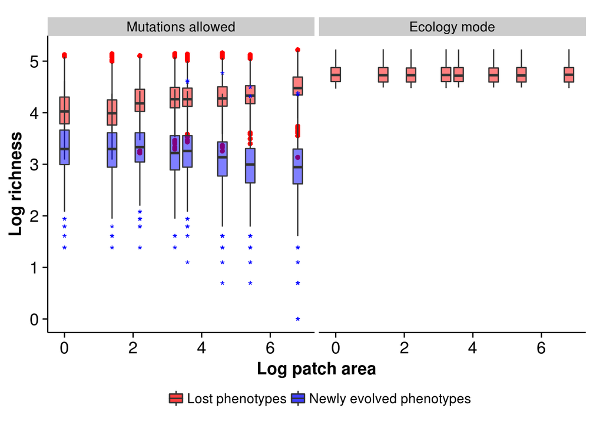

```r
ggplot(data=end_data_per_run,
       aes(group=(patch_size^2), #patch_size variable is edge length
      x=log(patch_size^2))) +
  geom_boxplot(aes(y=log(lost_phenotypes), fill="Lost phenotypes"), outlier.colour = "red",
               outlier.size = 2, alpha=.5) +
  geom_boxplot(aes(y=log(new_phenotypes), fill="Newly evolved phenotypes"), outlier.colour = "blue",
               outlier.shape = "*", outlier.size = 4, alpha=.5) +
  scale_x_continuous("Log patch area") + scale_y_continuous("Log richness") +
  scale_fill_manual("", values=c("red", "blue")) + theme(legend.position="bottom") +
  facet_grid(~ecology, labeller=function(variable, value){
        for (i in 1:length(value)){
          if (value[i]){
            value[i] <-  "Ecology mode"
          } else {
            value[i] <- "Mutations allowed"
            }
        }
      return(value)
      })
```

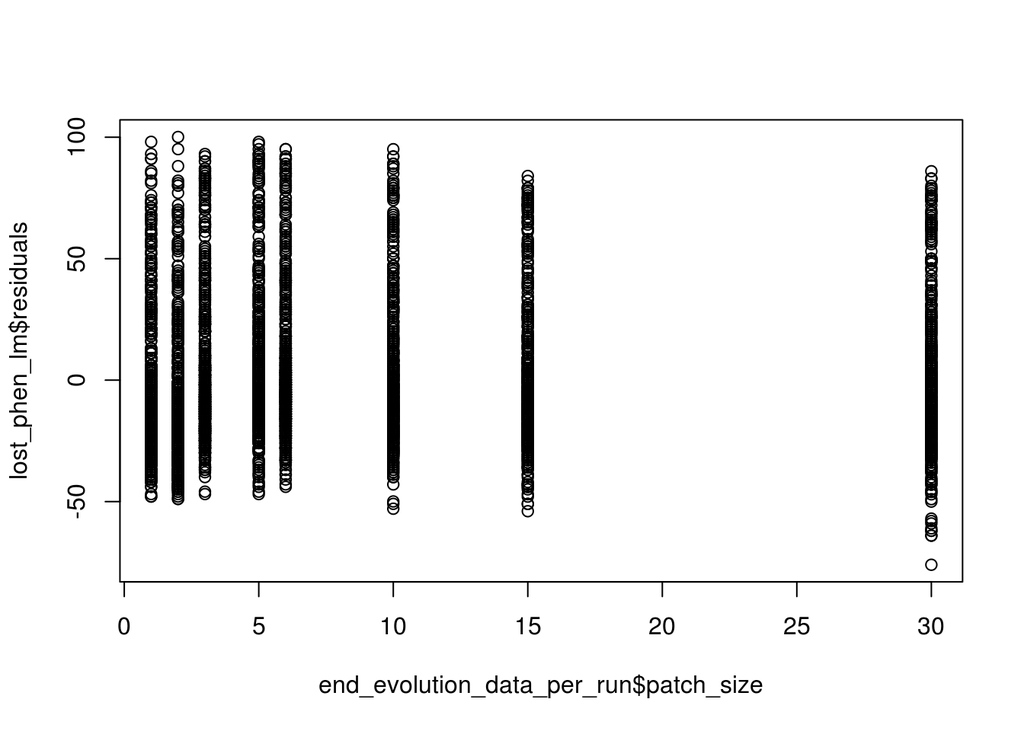

```r
lost_phen_lm <- lm(lost_phenotypes ~ patch_size^2, data=end_evolution_data_per_run) #let's see if we can get away with not taking the log so we don't have to worry about 0s

plot(lost_phen_lm$residuals ~ end_evolution_data_per_run$patch_size^2) #hmmm... not so much. There's a clear curve there
```

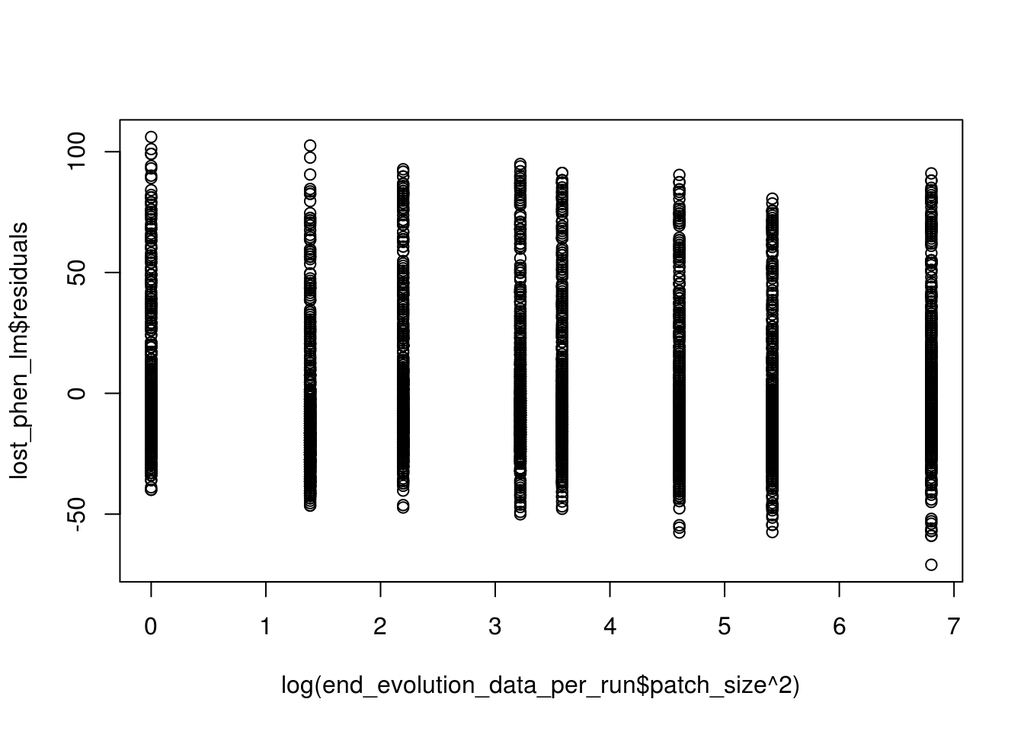

```r
lost_phen_lm <- lm(lost_phenotypes ~ log(patch_size^2), data=end_evolution_data_per_run) #how about we just log patches?

plot(lost_phen_lm$residuals ~ log(end_evolution_data_per_run$patch_size^2)) #much better!
```

```r
#plot(lost_phen_lm) #Other diagnostics look good too!
summary(lost_phen_lm)
```

```
##
## Call:
## lm(formula = lost_phenotypes ~ log(patch_size^2), data = end_evolution_data_per_run)
##
## Residuals:
##     Min      1Q  Median      3Q     Max
## -70.948 -19.427  -8.594  10.066 106.106
##
## Coefficients:
##                   Estimate Std. Error t value Pr(>|t|)
## (Intercept)        61.8944     0.9079   68.18   <2e-16 ***
## log(patch_size^2)   4.7121     0.2281   20.66   <2e-16 ***
## ---
## Signif. codes:  0 '***' 0.001 '**' 0.01 '*' 0.05 '.' 0.1 ' ' 1
##
## Residual standard error: 29.83 on 3998 degrees of freedom
## Multiple R-squared:  0.09647,    Adjusted R-squared:  0.09625
## F-statistic: 426.9 on 1 and 3998 DF,  p-value: < 2.2e-16
```

```r
#Of course, these totally aren't independent. Let's explicitly model the effect of initial population
lost_phen_lm <- lmer(lost_phenotypes ~ log(patch_size^2) + (1|initial_pop), data=end_evolution_data_per_run, REML=FALSE)
lost_phen_lm_null <- lmer(lost_phenotypes ~ 1 + (1|initial_pop), data=end_evolution_data_per_run, REML = FALSE)

summary(lost_phen_lm)
```

```
## Linear mixed model fit by maximum likelihood  ['lmerMod']
## Formula: lost_phenotypes ~ log(patch_size^2) + (1 | initial_pop)
##    Data: end_evolution_data_per_run
##
##      AIC      BIC   logLik deviance df.resid
##  32324.9  32350.1 -16158.5  32316.9     3996
##
## Scaled residuals:
##     Min      1Q  Median      3Q     Max
## -3.8161 -0.6015  0.0182  0.6477  3.5315
##
## Random effects:
##  Groups      Name        Variance Std.Dev.
##  initial_pop (Intercept) 704.0    26.53
##  Residual                185.5    13.62
## Number of obs: 4000, groups:  initial_pop, 10
##
## Fixed effects:
##                   Estimate Std. Error t value
## (Intercept)        61.8944     8.4010    7.37
## log(patch_size^2)   4.7121     0.1041   45.26
##
## Correlation of Fixed Effects:
##             (Intr)
## lg(ptch_^2) -0.042
```

```r
anova(lost_phen_lm_null, lost_phen_lm)
```

```
## Data: end_evolution_data_per_run
## Models:
## lost_phen_lm_null: lost_phenotypes ~ 1 + (1 | initial_pop)
## lost_phen_lm: lost_phenotypes ~ log(patch_size^2) + (1 | initial_pop)
##                   Df   AIC   BIC logLik deviance  Chisq Chi Df Pr(>Chisq)
## lost_phen_lm_null  3 33976 33995 -16985    33970
## lost_phen_lm       4 32325 32350 -16158    32317 1653.1      1  < 2.2e-16
##
## lost_phen_lm_null
## lost_phen_lm      ***
## ---
## Signif. codes:  0 '***' 0.001 '**' 0.01 '*' 0.05 '.' 0.1 ' ' 1
```

```r
summary(lm(new_phenotypes ~ log(patch_size^2), data=end_evolution_data_per_run))
```

```
##
## Call:
## lm(formula = new_phenotypes ~ log(patch_size^2), data = end_evolution_data_per_run)
##
## Residuals:
##     Min      1Q  Median      3Q     Max
## -27.482  -9.195  -2.120   6.805  93.408
##
## Coefficients:
##                   Estimate Std. Error t value Pr(>|t|)
## (Intercept)       31.48191    0.39521   79.66   <2e-16 ***
## log(patch_size^2) -1.49614    0.09928  -15.07   <2e-16 ***
## ---
## Signif. codes:  0 '***' 0.001 '**' 0.01 '*' 0.05 '.' 0.1 ' ' 1
##
## Residual standard error: 12.99 on 3998 degrees of freedom
## Multiple R-squared:  0.05375,    Adjusted R-squared:  0.05351
## F-statistic: 227.1 on 1 and 3998 DF,  p-value: < 2.2e-16
```

```r
summary(lm(lost_phenotypes ~ log(patch_size^2), data=end_ecology_data_per_run))
```

```
##
## Call:
## lm(formula = lost_phenotypes ~ log(patch_size^2), data = end_ecology_data_per_run)
##
## Residuals:
##     Min      1Q  Median      3Q     Max
## -34.573 -22.582  -9.573   9.394  65.418
##
## Coefficients:
##                    Estimate Std. Error t value Pr(>|t|)
## (Intercept)       1.216e+02  8.580e-01 141.700   <2e-16 ***
## log(patch_size^2) 5.978e-03  2.155e-01   0.028    0.978
## ---
## Signif. codes:  0 '***' 0.001 '**' 0.01 '*' 0.05 '.' 0.1 ' ' 1
##
## Residual standard error: 28.19 on 3998 degrees of freedom
## Multiple R-squared:  1.924e-07,  Adjusted R-squared:  -0.0002499
## F-statistic: 0.0007693 on 1 and 3998 DF,  p-value: 0.9779
```

```r
summary(lm(lost_phenotypes ~ log(patch_size^2)*ecology, data=end_data_per_run))
```

```
##
## Call:
## lm(formula = lost_phenotypes ~ log(patch_size^2) * ecology, data = end_data_per_run)
##
## Residuals:
##     Min      1Q  Median      3Q     Max
## -70.948 -21.582  -8.594   9.405 106.106
##
## Coefficients:
##                               Estimate Std. Error t value Pr(>|t|)
## (Intercept)                    61.8944     0.8833   70.08   <2e-16 ***
## log(patch_size^2)               4.7121     0.2219   21.24   <2e-16 ***
## ecologyTRUE                    59.6791     1.2491   47.78   <2e-16 ***
## log(patch_size^2):ecologyTRUE  -4.7061     0.3138  -15.00   <2e-16 ***
## ---
## Signif. codes:  0 '***' 0.001 '**' 0.01 '*' 0.05 '.' 0.1 ' ' 1
##
## Residual standard error: 29.02 on 7996 degrees of freedom
## Multiple R-squared:  0.3837, Adjusted R-squared:  0.3835
## F-statistic:  1660 on 3 and 7996 DF,  p-value: < 2.2e-16
```